# Deep C++(V17.02)

## RAII(scoped guard)

RAIIとは、「Resource Acquisition Is Initialization」の略語であり、 リソースの確保と解放をオブジェクトの初期化と破棄処理に結びつけるパターンもしくはイデオムである。 特にダイナミックにオブジェクトを生成する場合、 RAIIに従わないとメモリリークを防ぐことは困難である。

下記は、関数終了付近でdeleteする素朴なコードである。

```cpp
    // @@@ example/design_pattern/raii_ut.cpp 18

    // Aは外部の変数をリファレンスcounter_として保持し、
    //  * コンストラクタ呼び出し時に++counter_
    //  * デストラクタタ呼び出し時に--counter_
    // とするため、生成と解放が同じだけ行われれば外部の変数の値は0となる
    class A {
    public:
        A(uint32_t& couner) noexcept : counter_{++couner} {}
        ~A() { --counter_; }

    private:
        uint32_t& counter_;
    };

    char not_use_RAII_for_memory(size_t index, uint32_t& object_counter)
    {
        auto a = new A{object_counter};  // RAIIでない例
        auto s = std::string{"hehe"};

        auto ret = s.at(index);  // index >= 5でエクセプション発生

        // 何らかの処理

        delete a;         //  この行以前に関数を抜けるとaはメモリリーク

        return ret;
    }
```

このコードは下記の単体テストが示す通り、第1パラメータが5以上の場合、 エクセプションが発生しメモリリークしてしまう。

```cpp
    // @@@ example/design_pattern/raii_ut.cpp 71

    auto object_counter = 0U;

    // 第1引数が5なのでエクセプション発生
    ASSERT_THROW(not_use_RAII_for_memory(5, object_counter), std::exception);

    // 上記のnot_use_RAII_for_memoryではエクセプションが発生し、メモリリークする
    ASSERT_EQ(1, object_counter);
```

以下は、std::unique_ptrによってRAIIを導入し、この問題に対処した例である。

```cpp
    // @@@ example/design_pattern/raii_ut.cpp 83

    char use_RAII_for_memory(size_t index, uint32_t& object_counter)
    {
        auto a = std::make_unique<A>(object_counter);
        auto s = std::string{"hehe"};

        auto ret = s.at(index);  // index >= 5でエクセプション発生

        // 何らかの処理

        return ret;  // aは自動解放される
    }
```

下記単体テストで確認できるように、 エクセプション発生時にもstd::unique_ptrによる自動解放によりメモリリークは発生しない。

```cpp
    // @@@ example/design_pattern/raii_ut.cpp 100

    auto object_counter = 0U;

    // 第1引数が5なのでエクセプション発生
    ASSERT_THROW(use_RAII_for_memory(5, object_counter), std::exception);

    // 上記のuse_RAII_for_memoryではエクセプションが発生するがメモリリークはしない
    ASSERT_EQ(0, object_counter);
```

RAIIのテクニックはメモリ管理のみでなく、ファイルディスクリプタ(open-close、socket-close) 等のリソース管理においても有効であるという例を示す。

下記は、生成したソケットを関数終了付近でcloseする素朴なコードである。

```cpp
    // @@@ example/design_pattern/raii_ut.cpp 111

    // RAIIをしない例
    // 複数のclose()を書くような関数は、リソースリークを起こしやすい。
    void not_use_RAII_for_socket()
    {
        auto fd = socket(AF_INET, SOCK_STREAM, 0);

        try {
            // Do something
            ...
        }
        catch (std::exception const& e) {  // エクセプションはconstリファレンスで受ける。
            close(fd);                     // NG RAII未使用
            // Do something to recover
            ...

            return;
        }
        ...
        close(fd);  // NG RAII未使用
    }
```

エクセプションを扱うために関数の2か所でソケットをcloseしている。 この程度であれば大きな問題にはならないだろうが、実際には様々な条件が重なるため、 リソースの解放コードは醜悪にならざるを得ない。

このような場合には、下記するようなリソース解放用クラス

```cpp
    // @@@ h/scoped_guard.h 4

    /// @class ScopedGuard
    /// @brief RAIIのためのクラス。
    ///        コンストラクタ引数の関数オブジェクトをデストラクタから呼び出す。
    template <typename F>
    class ScopedGuard {
    public:
        explicit ScopedGuard(F&& f) noexcept : f_{f}
        {
            // f()がill-formedにならず、その戻りがvoidでなければならない
            static_assert(std::is_invocable_r_v<void, F>, "F must be callable and return void");
        }

        ~ScopedGuard() { f_(); }
        ScopedGuard(ScopedGuard const&)            = delete;  // copyは禁止
        ScopedGuard& operator=(ScopedGuard const&) = delete;  // copyは禁止

    private:
        F f_;
    };
```

を使用し、下記のようにすることで安全なコードをすっきりと書くことができる。

```cpp
    // @@@ example/design_pattern/raii_ut.cpp 138

    // RAIIをScopedGuardで行った例。
    // close()が自動実行されるためにリソース解放を忘れない。
    void use_RAII_for_socket()
    {
        auto fd    = socket(AF_INET, SOCK_STREAM, 0);
        auto guard = ScopedGuard{[fd] { close(fd); }};  // 関数終了時に自動実行

        try {
            // Do something
        }
        catch (...) {
            // Do something to recover

            return;
        }
        ...
    }
```

クリティカルセクションの保護をlock/unlockで行うstd::mutex等を使う場合にも、 std::lock_guard<>によってunlockを行うことで、同様の効果が得られる。

## Future

[Future](https://ja.wikipedia.org/wiki/Future_%E3%83%91%E3%82%BF%E3%83%BC%E3%83%B3)とは、 並行処理のためのデザインパターンであり、別スレッドに何らかの処理をさせる際、 その結果の取得を、必要になるまで後回しにする手法である。

C++11では、std::future, std::promise, std::asyncによって実現できる。

まずは、C++03以前のスタイルから示す。

```cpp
    // @@@ example/design_pattern/future_ut.cpp 11

    int do_something(std::string_view str0, std::string_view str1) noexcept
    {
        ...

        return ret0 + ret1;
    }

    TEST(Future, old_style)
    {
        auto str0 = std::string{};
        auto th0  = std::thread{[&str0]() noexcept { str0 = do_heavy_algorithm("thread 0"); }};

        auto str1 = std::string{};
        auto th1  = std::thread{[&str1]() noexcept { str1 = do_heavy_algorithm("thread 1"); }};

        //
        // このスレッドで行うべき何らかの処理
        //

        th0.join();
        th1.join();

        ASSERT_EQ("THREAD 0", str0);
        ASSERT_EQ("THREAD 1", str1);

        ASSERT_EQ(16, do_something(str0, str1));
    }
```

上記は、

1. 時間がかかる処理を並行して行うために、スレッドを二つ作る。
2. それぞれの完了をthread::join()で待ち合わせる。
3. その結果を参照キャプチャによって受け取る。
4. その2つの結果を別の関数に渡す。

という処理を行っている。

この程度の単純なコードでは特に問題にはならないが、目的外の処理が多いことがわかるだろう。

次にFutureパターンによって上記をリファクタリングした例を示す。

```cpp
    // @@@ example/design_pattern/future_ut.cpp 45

    TEST(Future, new_style)
    {
        std::future<std::string> result0
            = std::async(std::launch::async, []() noexcept { return do_heavy_algorithm("thread 0"); });

        std::future<std::string> result1
            = std::async(std::launch::async, []() noexcept { return do_heavy_algorithm("thread 1"); });

        // futre::get()は処理の待ち合わせと値の取り出しを行う。
        auto str0 = result0.get();
        auto str1 = result1.get();
        ASSERT_EQ(16, do_something(str0, str1));

        ASSERT_EQ("THREAD 0", str0);
        ASSERT_EQ("THREAD 1", str1);
    }
```

リファクタリングした例では、時間のかかる処理をstd::future型のオブジェクトにし、 その結果を必要とする関数に渡すことができるため、目的をよりダイレクトに表すことができる。

なお、

```cpp
    std::async(関数オブジェクト)
```

という形式を使った場合、関数オブジェクトは、

```cpp
    std::launch::async | std::launch::deferred
```

が指定されたとして実行される。この場合、

```cpp
    std::launch::deferred
```

の効果により、関数オブジェクトは、並行に実行されるとは限らない (この仕様はランタイム系に依存しており、std::future::get()のコンテキストで実行されることもあり得る)。 従って、並行実行が必要な場合、上記例のように

```cpp
    std::launch::async
```

のみを明示的に指定するべきである。

## DI(dependency injection)

メンバ関数内でクラスDependedのオブジェクトを直接、生成する (もしくはSingletonオブジェクトや静的オブジェクト(std::coutやstd::cin等)に直接アクセスする) クラスNotDIがあるとする。 この場合、クラスNotDIはクラスDependedのインスタンスに依存してしまう。 このような依存関係はクラスNotDIの可用性とテスト容易性を下げる。 これは、「仮にクラスDependedがデータベースをラップするクラスだった場合、 クラスNotDIの単体テストにデータベースが必要になる」ことからも容易に理解できる。

```cpp
    // @@@ example/design_pattern/di_ut.cpp 8

    /// @class Depended
    /// @brief NotDIや、DIから依存されるクラス
    class Depended {
        ...
    };

    /// @class NotDI
    /// @brief NotDIを使わない例。そのため、NotDIは、Dependedのインスタンスに依存している。
    class NotDI {
    public:
        NotDI() : not_di_depended_{std::make_unique<Depended>()} {}

        void DoSomething() { not_di_depended_->DoSomething(); }

    private:
        std::unique_ptr<Depended> not_di_depended_;
    };
```

下記は上記NotDIにDIパターンを適用した例である。 この場合、クラスDIは、クラスDependedの型にのみ依存する。

```cpp
    // @@@ example/design_pattern/di_ut.cpp 39

    /// @class DI
    /// @brief DIを使う例。そのため、DIは、Dependedの型に依存している。
    class DI {
    public:
        explicit DI(std::unique_ptr<Depended>&& di_depended) noexcept
            : di_depended_{std::move(di_depended)}
        {
        }

        void DoSomething() { di_depended_->DoSomething(); }

    private:
        std::unique_ptr<Depended> di_depended_;
    };
```

下記は、クラスNotDIとクラスDIがそれぞれのDoSomething()を呼び出すまでのシーケンス図である。

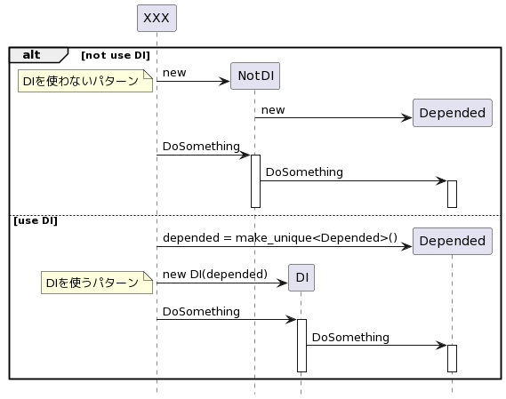

このパターンの効果により、 DIオブジェクトにはDependedかその派生クラスのオブジェクトを渡すことができるようになった。 これによりクラスDIは拡張性に対して柔軟になっただけでなく、テスト容易性も向上した。

次に示すのは、このパターンを使用して問題のある単体テストを修正した例である。

まずは、問題があるクラスとその単体テストを下記する。

```cpp
    // in device_io.h

    class DeviceIO {
    public:
        uint8_t read()
        {
            // ハードウェアに依存した何らかの処理
        }

        void write(uint8_t a)
        {
            // ハードウェアに依存した何らかの処理
        }

    private:
        // 何らかの宣言
    };

    #ifdef UNIT_TEST       // 単体テストビルドでは定義されるマクロ
    class DeviceIO_Mock {  // 単体テスト用のモック
    public:
        uint8_t read()
        {
            // ハードウェアに依存しない何らかの処理
        }

        void write(uint8_t a)
        {
            // ハードウェアに依存しない何らかの処理
        }

    private:
        // 何らかの宣言
    };
    #endif
```

```cpp
    // in widget.h

    #include "device_io.h"

    class Widget {
    public:
        void DoSomething()
        {
            // io_を使った何らかの処理
        }

        uint8_t GetResp()
        {
            // io_を使った何らかの処理
        }

    private:
    #ifdef UNIT_TEST
        DeviceIO_Mock io_;
    #else
        DeviceIO io_;
    #endif
    };
```

```cpp
    // in widget_ut.cpp

    // UNIT_TESTマクロが定義されたWidgetの単体テスト
    Widget w;

    w.DoSomething();
    ASSERT_EQ(0, w.GetResp());
```

当然であるが、この単体テストは、UNIT_TESTマクロを定義している場合のWidgetの評価であり、 UNIT_TESTを定義しない実際のコードの評価にはならない。

以下では、DIを用い、この問題を回避する。

```cpp
    // in device_io.h

    class DeviceIO {
    public:
        virtual uint8_t read()  // モックでオーバーライドするためvirtual
        {
            // ハードウェアに依存した何らかの処理
        }

        virtual void write(uint8_t a)  // モックでオーバーライドするためvirtual
        {
            // ハードウェアに依存した何らかの処理
        }
        virtual ~DeviceIO() = default;

    private:
        // 何らかの宣言
    };
```

```cpp
    // in widget.h

    class Widget {
    public:
        Widget(std::unique_ptr<DeviceIO> io = std::make_unique<DeviceIO>()) : io_{std::move(io)} {}

        void DoSomething()
        {
            // io_を使った何らかの処理
        }

        uint8_t GetResp()
        {
            // io_を使った何らかの処理
        }

    private:
        std::unique_ptr<DeviceIO> io_;
    };
```

```cpp
    // in widget_ut.cpp

    class DeviceIO_Mock : public DeviceIO {  // 単体テスト用のモック
    public:
        uint8_t read() override
        {
            // ハードウェアに依存しない何らかの処理
        }

        void write(uint8_t a) override
        {
            // ハードウェアに依存しない何らかの処理
        }

    private:
        // 何らかの宣言
    };
```

```cpp
    // 上記DeviceIO_Mockと同様に、in widget_ut.cpp

    Widget w{std::unique_ptr<DeviceIO>(new DeviceIO_Mock)};  // モックのインジェクション

    // Widgetの単体テスト
    w.DoSomething();
    ASSERT_EQ(1, w.GetResp());
```

この例では、単体テストのためだけに仮想関数を導入しているため、多少やりすぎの感がある。 そのような場合、下記のようにテンプレートを用いればよい。

```cpp
    // in device_io.h

    class DeviceIO {
    public:
        uint8_t read()  // Widgetがテンプレートであるため非virtualで良い
        {
            // ハードウェアに依存した何らかの処理
        }

        void write(uint8_t a)  // Widgetがテンプレートであるため非virtualで良い
        {
            // ハードウェアに依存した何らかの処理
        }
        virtual ~DeviceIO() = default;

    private:
        // 何らかの宣言
    };
```

```cpp
    // in widget.h

    template <class T = DeviceIO>
    class Widget {
    public:
        void DoSomething()
        {
            // io_を使った何らかの処理
        }

        uint8_t GetResp()
        {
            // io_を使った何らかの処理
        }

    private:
        T io_;
    };
```

```cpp
    // in widget_ut.cpp

    class DeviceIO_Mock {  // 単体テスト用のモック
    public:
        uint8_t read()  // Widgetがテンプレートであるため非virtualで良い
        {
            // ハードウェアに依存しない何らかの処理
        }

        void write(uint8_t a)  // Widgetがテンプレートであるため非virtualで良い
        {
            // ハードウェアに依存しない何らかの処理
        }

    private:
        // 何らかの宣言
    };
```

```cpp
    // 上記DeviceIO_Mockと同様に、in widget_ut.cpp

    Widget<DeviceIO_Mock> w;

    // Widget<>の単体テスト
    w.DoSomething();
    ASSERT_EQ(2, w.GetResp());
```

以上からわかるように、 ここで紹介したDIは単体テストを容易にするクラス設計のためにも非常に有用なパターンである。

## Singleton

このパターンにより、特定のクラスのインスタンスをシステム全体で唯一にすることができる。 これにより、グローバルオブジェクトを規律正しく使用しやすくなる。

以下は、Singletonの実装例である。

```cpp
    // @@@ example/design_pattern/singleton_ut.cpp 7

    class Singleton final {
    public:
        static Singleton&       Inst();
        static Singleton const& InstConst() noexcept  // constインスタンスを返す
        {
            return Inst();
        }
        ...

    private:
        Singleton() noexcept {}  // コンストラクタをprivateにすることで、
                                 // Inst()以外ではこのオブジェクトを生成できない。
        ...
    };

    Singleton& Singleton::Inst()
    {
        static Singleton inst;  //  instの初期化が同時に行われることはない。

        return inst;
    }

    TEST(Singleton, how_to_use)
    {
        auto&       inst       = Singleton::Inst();
        auto const& inst_const = Singleton::InstConst();

        ASSERT_EQ(0, inst.GetXxx());
        ASSERT_EQ(0, inst_const.GetXxx());
    #if 0
        inst_const.SetXxx(10);  // inst_constはconstオブジェクトなのでコンパイルエラー
    #else
        inst.SetXxx(10);
    #endif
        ASSERT_EQ(10, inst.GetXxx());
        ASSERT_EQ(10, inst_const.GetXxx());

        inst.SetXxx(0);
        ASSERT_EQ(0, inst.GetXxx());
        ASSERT_EQ(0, inst_const.GetXxx());
    }
    }  // namespace
```

このパターンを使用する場合、以下に注意する。

- Singletonはデザインパターンの中でも、特にパターン猿病を発生しやすい。 Singletonは「ほとんどグローバル変数である」ことを理解した上で、控えめに使用する。
- Singletonを定義する場合、以下の二つを定義する。
  - インスタンスを返すstaticメンバ関数Inst()
  - constインスタンスを返すstaticメンバ関数InstConst()
- InstConst()は、Inst()が返すオブジェクトと同じオブジェクトを返すようにする。
- Singletonには、可能な限りInstConst()経由でアクセスする。

Singletonオブジェクトの初期化(最初のコンストラクタ呼び出し)は、 C++03以前はスレッドセーフでなかったため、「 Double Checked Lockingを使って競合を避ける」か、 「他のスレッドを起動する前にメインスレッドから各SingletonのInstConst()を呼び出す」 ことが必要であった。 C++11から上記例のようなSingletonオブジェクトのコンストラクタ呼び出しはスレッドセーフとなったため、 このような黒魔術が不要になった。

なお、Inst()のような関数を複数定義する場合、そのパターンはNamed Constructor (「Named Constructor」参照)と呼ばれる。

## State

Stateは、オブジェクトの状態と、それに伴う振る舞いを分離して記述するためのパターンである。 これにより状態の追加、削減、変更に伴う修正範囲が限定される (「オープン・クローズドの原則(OCP)」参照)。 またオブジェクトのインターフェース変更(パブリックメンバ関数の変更)に関しても、修正箇所が明確になる。

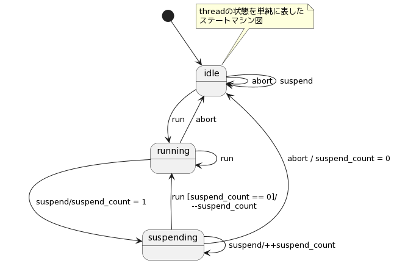

上記ステートマシン図の「オールドスタイルによる実装」と、「stateパターンによる実装」、 それぞれを例示する。

まずは、下記にオールドスタイルな実装例を示す。 この実装では、状態を静的なenum変数thread_old_style_stateで管理するため、 ThreadOldStyleStateStr()、ThreadOldStyleRun()、ThreadOldStyleAbort()、ThreadOldStyleSuspend() には、thread_old_style_stateに対する同型のswitch文が入ることになる(下記例では一部省略)。 これは醜悪で、バグを起こしやすい構造である。 ただし、要求される状態遷移がこの例程度であり、状態ごとに決められた振る舞いの数が少なければ、 この構造でも問題ないともいえる。

```cpp
    // @@@ example/design_pattern/state_machine_old.h 4

    extern std::string_view ThreadOldStyleStateStr() noexcept;
    extern void             ThreadOldStyleRun();
    extern void             ThreadOldStyleAbort();
    extern void             ThreadOldStyleSuspend();
```

```cpp
    // @@@ example/design_pattern/state_machine_old.cpp 6

    namespace {
    enum class ThreadOldStyleState {
        Idle,
        Running,
        Suspending,
    };

    ThreadOldStyleState thread_old_style_state;
    ...
    }  // namespace

    std::string_view ThreadOldStyleStateStr() noexcept
    {
        switch (thread_old_style_state) {  // このswitch文と同型switch文が何度も記述される
        case ThreadOldStyleState::Idle:
            return "Idle";
        case ThreadOldStyleState::Running:
            return "Running";
        case ThreadOldStyleState::Suspending:
            return "Suspending";
        default:
            assert(false);
            return "";
        }
    }

    void ThreadOldStyleRun()
    {
        switch (thread_old_style_state) {
        case ThreadOldStyleState::Idle:
        case ThreadOldStyleState::Running:
            thread_old_style_state = ThreadOldStyleState::Running;
            break;
        case ThreadOldStyleState::Suspending:
            --thread_old_style_suspend_count;
            if (thread_old_style_suspend_count == 0) {
                thread_old_style_state = ThreadOldStyleState::Running;
            }
            break;
        default:
            assert(false);
        }
    }

    void ThreadOldStyleAbort()
    {
        ...
    }

    void ThreadOldStyleSuspend()
    {
        ...
    }
```

```cpp
    // @@@ example/design_pattern/state_machine_ut.cpp 15

    // ステートのテスト。仕様書よりも単体テストでその仕様や使用法を記述したほうが正確に理解できる。
    TEST(StateMachine, old_style)
    {
        ASSERT_EQ("Idle", ThreadOldStyleStateStr());

        ThreadOldStyleAbort();
        ASSERT_EQ("Idle", ThreadOldStyleStateStr());

        ThreadOldStyleRun();
        ASSERT_EQ("Running", ThreadOldStyleStateStr());

        ThreadOldStyleRun();
        ASSERT_EQ("Running", ThreadOldStyleStateStr());

        ThreadOldStyleSuspend();
        ASSERT_EQ("Suspending", ThreadOldStyleStateStr());  // suspend_count_ == 1

        ThreadOldStyleSuspend();
        ASSERT_EQ("Suspending", ThreadOldStyleStateStr());  // suspend_count_ == 2

        ThreadOldStyleRun();
        ASSERT_EQ("Suspending", ThreadOldStyleStateStr());  // suspend_count_ == 1

        ...
    }
```

下記は、上記例へstateパターンを適用した例である。 まずは、stateパターンを形成するクラスの関係をクラス図で示す。

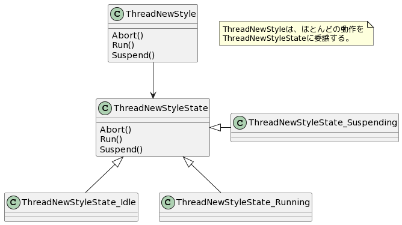

次に上記クラス図の実装例を示す。

```cpp
    // @@@ example/design_pattern/state_machine_new.h 6

    /// @class ThreadNewStyleState
    /// @brief ThreadNewStyleのステートを表す基底クラス
    class ThreadNewStyleState {
    public:
        ThreadNewStyleState()          = default;
        virtual ~ThreadNewStyleState() = default;

        std::unique_ptr<ThreadNewStyleState> Abort()  // NVI
        {
            return abort_thread();
        }

        std::unique_ptr<ThreadNewStyleState> Run()  // NVI
        {
            return run_thread();
        }

        std::unique_ptr<ThreadNewStyleState> Suspend()  // NVI
        {
            return suspend_thread();
        }

        std::string_view GetStateStr() const noexcept { return get_state_str(); }

    private:
        virtual std::unique_ptr<ThreadNewStyleState> abort_thread()
        {
            return {};  // デフォルトでは何もしない。
        }

        virtual std::unique_ptr<ThreadNewStyleState> run_thread()
        {
            return {};  // デフォルトでは何もしない。
        }

        virtual std::unique_ptr<ThreadNewStyleState> suspend_thread()
        {
            return {};  // デフォルトでは何もしない。
        }

        virtual std::string_view get_state_str() const noexcept = 0;
    };
```

```cpp
    // @@@ example/design_pattern/state_machine_new.h 52

    class ThreadNewStyle final {
    public:
        ThreadNewStyle();

        void Abort() { change_state(state_->Abort()); }

        void Run() { change_state(state_->Run()); }

        void Suspend() { change_state(state_->Suspend()); }

        std::string_view GetStateStr() const noexcept { return state_->GetStateStr(); }

    private:
        std::unique_ptr<ThreadNewStyleState> state_;

        void change_state(std::unique_ptr<ThreadNewStyleState>&& new_state) noexcept
        {
            if (new_state) {
                state_ = std::move(new_state);
            }
        }
    };
```

```cpp
    // @@@ example/design_pattern/state_machine_new.cpp 10

    class ThreadNewStyleState_Idle final : public ThreadNewStyleState {
        ...
    };

    class ThreadNewStyleState_Running final : public ThreadNewStyleState {
        ...
    };

    class ThreadNewStyleState_Suspending final : public ThreadNewStyleState {
    public:
        ...
    private:
        virtual std::unique_ptr<ThreadNewStyleState> abort_thread() override
        {
            // do something to abort
            ...

            return std::make_unique<ThreadNewStyleState_Idle>();
        }

        virtual std::unique_ptr<ThreadNewStyleState> run_thread() override
        {
            --suspend_count_;

            if (suspend_count_ == 0) {
                // do something to resume
                ...
                return std::make_unique<ThreadNewStyleState_Running>();
            }
            else {
                return {};
            }
        }

        virtual std::unique_ptr<ThreadNewStyleState> suspend_thread() override
        {
            ++suspend_count_;

            return {};
        }
        ...
    };
```

```cpp
    // @@@ example/design_pattern/state_machine_ut.cpp 57

    TEST(StateMachine, new_style)
    {
        auto tns = ThreadNewStyle{};

        ASSERT_EQ("Idle", tns.GetStateStr());

        tns.Abort();
        ASSERT_EQ("Idle", tns.GetStateStr());

        tns.Run();
        ASSERT_EQ("Running", tns.GetStateStr());

        tns.Run();
        ASSERT_EQ("Running", tns.GetStateStr());

        tns.Suspend();
        ASSERT_EQ("Suspending", tns.GetStateStr());  // suspend_count_ == 1

        tns.Suspend();
        ASSERT_EQ("Suspending", tns.GetStateStr());  // suspend_count_ == 2

        tns.Run();
        ASSERT_EQ("Suspending", tns.GetStateStr());  // suspend_count_ == 1

        ...
    }
```

オールドスタイルな構造に比べると一見複雑に見えるが同型のswitch構造がないため、 状態の増減や振る舞いの変更等への対応が容易である。 一方で、前述したとおり、この例程度の要求であれば、 シンプルさという意味においてオールドスタイルのソースコードの方が優れているともいえる。 従って、オールドスタイルとstateパターンの選択は、 その要求の複雑さと安定度によって決定されるべきものである。

なお、C++でのstateパターンの実装には、下記に示すようなメンバ関数を使う方法もある。 多くのクラスを作る必要はないが、 各状態での状態管理変数を別の状態のものと分けて管理することができないため、 複雑な状態管理が必要な場合には使えないが、単純な状態管理で十分な場合には便利なパターンである。

```cpp
    // @@@ example/design_pattern/state_machine_new.h 77

    class ThreadNewStyle2 final {
    public:
        ThreadNewStyle2() noexcept {}

        void             Abort() { (this->*abort_)(); }
        void             Run() { (this->*run_)(); }
        void             Suspend() { (this->*suspend_)(); }
        std::string_view GetStateStr() const noexcept { return state_str_; }

    private:
        void (ThreadNewStyle2::*abort_)()   = &ThreadNewStyle2::abort_idle;
        void (ThreadNewStyle2::*run_)()     = &ThreadNewStyle2::run_idle;
        void (ThreadNewStyle2::*suspend_)() = &ThreadNewStyle2::suspend_idle;
        std::string_view state_str_{state_str_idle_};

        void                                 abort_idle() {}  // do nothing
        void                                 run_idle();
        void                                 suspend_idle() {}  // do nothing
        static inline std::string_view const state_str_idle_{"Idle"};

        void                                 abort_running();
        void                                 run_running() {}  // do nothing
        void                                 suspend_running();
        static inline std::string_view const state_str_running_{"Running"};

        void                                 abort_suspending();
        void                                 run_suspending();
        void                                 suspend_suspending() {}  // do nothing
        static inline std::string_view const state_str_suspending_{"Suspending"};
    };
```

```cpp
    // @@@ example/design_pattern/state_machine_new.cpp 106

    void ThreadNewStyle2::run_idle()
    {
        // スレッドの始動処理
        ...

        // ステートの切り替え
        run_       = &ThreadNewStyle2::run_running;
        suspend_   = &ThreadNewStyle2::suspend_running;
        state_str_ = state_str_running_;
    }

    void ThreadNewStyle2::abort_running()
    {
        // スレッドのアボート処理
        ...

        // ステートの切り替え
        run_       = &ThreadNewStyle2::run_idle;
        suspend_   = &ThreadNewStyle2::suspend_idle;
        state_str_ = state_str_idle_;
    }

    void ThreadNewStyle2::suspend_running()
    {
        // スレッドのサスペンド処理
        ...

        // ステートの切り替え
        run_       = &ThreadNewStyle2::run_suspending;
        suspend_   = &ThreadNewStyle2::suspend_suspending;
        state_str_ = state_str_suspending_;
    }

    void ThreadNewStyle2::run_suspending()
    {
        // スレッドのレジューム処理
        ...

        // ステートの切り替え
        run_       = &ThreadNewStyle2::run_running;
        suspend_   = &ThreadNewStyle2::suspend_running;
        state_str_ = state_str_running_;
    }
```

```cpp
    // @@@ example/design_pattern/state_machine_ut.cpp 95

    TEST(StateMachine, new_style2)
    {
        auto tns = ThreadNewStyle2{};

        ASSERT_EQ("Idle", tns.GetStateStr());

        tns.Run();
        ASSERT_EQ("Running", tns.GetStateStr());

        tns.Suspend();
        ASSERT_EQ("Suspending", tns.GetStateStr());

        tns.Suspend();
        ASSERT_EQ("Suspending", tns.GetStateStr());
    }
```

## Null Object

オブジェクトへのポインタを受け取った関数が 「そのポインタがnullptrでない場合、そのポインタが指すオブジェクトに何かをさせる」 というような典型的な条件文を削減するためのパターンである。

```cpp
    // @@@ example/design_pattern/null_object_ut.cpp 7

    class A {
    public:
        ...
        bool Action() noexcept
        {
            // do something
            ...
            return result;
        }
        ...
    };

    bool ActionOldStyle(A* a) noexcept
    {
        if (a != nullptr) {  // ←このif文を消すためのパターン。
            return a->Action();
        }
        else {
            return false;
        }
    }
```

上記例にNull Objectパターンを適用した例を下記する。

```cpp
    // @@@ example/design_pattern/null_object_ut.cpp 41

    class A {
    public:
        ...
        bool Action() noexcept { return action(); }

    private:
        virtual bool action() noexcept
        {
            // do something
            ...
            return result;
        }
        ...
    };

    class ANull final : public A {
        ...
    private:
        virtual bool action() noexcept override { return false; }
    };

    bool ActionNewStyle(A& a) noexcept
    {
        return a.Action();  // ←Null Objectによりif文が消えた。
    }
```

この単純な例では、逆にソースコードが複雑化したように見えるが、

```cpp
    if(a != nullptr)
```

を頻繁に使うような関数、 クラスではソースコードの単純化やnullptrチェック漏れの防止に非常に有効である。

## Templateメソッド

Templateメソッドは、雛形の形式(書式等)を定めるメンバ関数(templateメソッド)と、 それを埋めるための振る舞いやデータを定めるメンバ関数を分離するときに用いるパターンである。

以下に実装例を示す。

```cpp
    // @@@ example/design_pattern/template_method.h 6

    /// @class XxxData
    /// @brief 何かのデータを入れる箱
    struct XxxData {
        int a;
        int b;
        int c;
    };

    /// @class XxxDataFormatterIF
    /// @brief data_storer_if.cppに定義すべきだが、サンプルであるため便宜上同じファイルで定義する
    ///        データフォーマットを行うクラスのインターフェースクラス
    class XxxDataFormatterIF {
    public:
        explicit XxxDataFormatterIF(std::string_view formatter_name) noexcept
            : formatter_name_{formatter_name}
        {
        }
        virtual ~XxxDataFormatterIF() = default;

        std::string ToString(XxxData const& xxx_data) const
        {
            return header() + body(xxx_data) + footer();
        }

        std::string ToString(std::vector<XxxData> const& xxx_datas) const
        {
            std::string ret{header()};

            for (auto const& xxx_data : xxx_datas) {
                ret += body(xxx_data);
            }

            return ret + footer();
        }
        ...
    private:
        virtual std::string const& header() const                      = 0;
        virtual std::string const& footer() const                      = 0;
        virtual std::string        body(XxxData const& xxx_data) const = 0;

        ...
    };
```

上記XxxDataFormatterIFでは、以下のようなメンバ関数を宣言、定義している。

| メンバ関数 |  | 振る舞い |
| --- | --- | --- |
| header() | private pure-virtual | ヘッダをstd::stringオブジェクトとして生成 |
| footer() | private pure-virtual | フッタをstd::stringオブジェクトとして生成 |
| body() | private pure-virtual | XxxDataからボディをstd::stringオブジェクトとして生成 |
| ToString() | public normal | header(),body(),footer()の出力を組み合わせた全体像を生成 |

この構造により、XxxDataFormatterIFは、

- 全体の書式を定義している。
- 各行の生成をXxxDataFormatterIFから派生した具象クラスに委譲している。

下記XxxDataFormatterXml、XxxDataFormatterCsv、XxxDataFormatterTableでは、 header()、body()、footer()をオーバーライドすることで、それぞれの機能を実現している。

```cpp
    // @@@ example/design_pattern/template_method.cpp 8

    /// @class XxxDataFormatterXml
    /// @brief XxxDataをXmlに変換
    class XxxDataFormatterXml final : public XxxDataFormatterIF {
        ...
    private:
        virtual std::string const& header() const noexcept final { return header_; }
        virtual std::string const& footer() const noexcept final { return footer_; }
        virtual std::string        body(XxxData const& xxx_data) const override
        {
            auto content = std::string{"<Item>\n"};

            content += "    <XxxData a=\"" + std::to_string(xxx_data.a) + "\">\n";
            content += "    <XxxData b=\"" + std::to_string(xxx_data.b) + "\">\n";
            content += "    <XxxData c=\"" + std::to_string(xxx_data.c) + "\">\n";

            return content + "</Itemp>\n";
        }

        static inline std::string const header_{
            "<?xml version=\"1.0\" encoding=\"UTF-8\" ?>\n<XxxDataFormatterXml>\n"};
        static inline std::string const footer_{"</XxxDataFormatterXml>\n"};
    };

    /// @class XxxDataFormatterCsv
    /// @brief XxxDataをCsvに変換
    class XxxDataFormatterCsv final : public XxxDataFormatterIF {
        ...
    private:
        virtual std::string const& header() const noexcept final { return header_; }
        virtual std::string const& footer() const noexcept final { return footer_; }
        virtual std::string        body(XxxData const& xxx_data) const override
        {
            return std::string{std::to_string(xxx_data.a) + ", " + std::to_string(xxx_data.b) + ", "
                               + std::to_string(xxx_data.b) + "\n"};
        }

        static inline std::string const header_{"a, b, c\n"};
        static inline std::string const footer_{};
    };

    /// @class XxxDataFormatterTable
    /// @brief XxxDataをTableに変換
    class XxxDataFormatterTable final : public XxxDataFormatterIF {
        ...
    private:
        virtual std::string const& header() const noexcept final { return header_; }
        virtual std::string const& footer() const noexcept final { return footer_; }
        virtual std::string        body(XxxData const& xxx_data) const override
        {
            auto a = std::string{std::string{"| "} + std::to_string(xxx_data.a)};
            auto b = std::string{std::string{"| "} + std::to_string(xxx_data.b)};
            auto c = std::string{std::string{"| "} + std::to_string(xxx_data.c)};

            a += std::string(colomun_ - a.size() + 1, ' ');
            b += std::string(colomun_ - b.size() + 1, ' ');
            c += std::string(colomun_ - c.size() + 1, ' ');

            return a + b + c + "|\n" + border_;
        }
        ...
    };
```

以下の単体テストで、これらのクラスの振る舞いを示す。

```cpp
    // @@@ example/design_pattern/template_method_ut.cpp 6

    TEST(TemplateMethod, xml)
    {
        auto xml = XxxDataFormatterXml{};

        {
            auto const xd     = XxxData{1, 100, 10};
            auto const expect = std::string_view{
                "<?xml version=\"1.0\" encoding=\"UTF-8\" ?>\n"
                "<XxxDataFormatterXml>\n"
                "<Item>\n"
                "    <XxxData a=\"1\">\n"
                "    <XxxData b=\"100\">\n"
                "    <XxxData c=\"10\">\n"
                "</Itemp>\n"
                "</XxxDataFormatterXml>\n"};
            auto const actual = xml.ToString(xd);

            ASSERT_EQ(expect, actual);
        }
        {
            auto const xds    = std::vector<XxxData>{{1, 100, 10}, {2, 200, 20}};
            auto const expect = std::string_view{
                "<?xml version=\"1.0\" encoding=\"UTF-8\" ?>\n"
                "<XxxDataFormatterXml>\n"
                "<Item>\n"
                "    <XxxData a=\"1\">\n"
                "    <XxxData b=\"100\">\n"
                "    <XxxData c=\"10\">\n"
                "</Itemp>\n"
                "<Item>\n"
                "    <XxxData a=\"2\">\n"
                "    <XxxData b=\"200\">\n"
                "    <XxxData c=\"20\">\n"
                "</Itemp>\n"
                "</XxxDataFormatterXml>\n"};
            auto const actual = xml.ToString(xds);

            ASSERT_EQ(expect, actual);
        }
    }

    TEST(TemplateMethod, csv)
    {
        auto csv = XxxDataFormatterCsv{};

        {
            auto const xd     = XxxData{1, 100, 10};
            auto const expect = std::string_view{
                "a, b, c\n"
                "1, 100, 100\n"};
            auto const actual = csv.ToString(xd);

            ASSERT_EQ(expect, actual);
        }
        {
            auto const xds    = std::vector<XxxData>{{1, 100, 10}, {2, 200, 20}};
            auto const expect = std::string_view{
                "a, b, c\n"
                "1, 100, 100\n"
                "2, 200, 200\n"};
            auto const actual = csv.ToString(xds);

            ASSERT_EQ(expect, actual);
        }
    }

    TEST(TemplateMethod, table)
    {
        auto table = XxxDataFormatterTable{};

        ...
    }
```

上記で示した実装例は、public継承による動的ポリモーフィズムを使用したため、 XxxDataFormatterXml、XxxDataFormatterCsv、XxxDataFormatterTableのインスタンスやそのポインタは、 XxxDataFormatterIFのリファレンスやポインタとして表現できる。 この性質は、FactoryやNamed Constructorの実装には不可欠であるが、 逆にこのようなポリモーフィズムが不要な場合、このよう柔軟性も不要である。

そういった場合、private継承を用いるか、 テンプレートを用いた静的ポリモーフィズムを用いることでこの柔軟性を排除できる。

下記のコードはそのような実装例である。

```cpp
    // @@@ example/design_pattern/template_method_ut.cpp 111

    template <typename T>  // Tは下記のXxxDataFormatterXmlのようなクラス
    class XxxDataFormatter : private T {
    public:
        std::string ToString(XxxData const& xxx_data) const
        {
            return T::Header() + T::Body(xxx_data) + T::Footer();
        }

        std::string ToString(std::vector<XxxData> const& xxx_datas) const
        {
            auto ret = std::string{T::Header()};

            for (auto const& xxx_data : xxx_datas) {
                ret += T::Body(xxx_data);
            }

            return ret + T::Footer();
        }
    };

    class XxxDataFormatterXml_Impl {
    public:
        std::string const& Header() const noexcept { return header_; }
        std::string const& Footer() const noexcept { return footer_; }
        std::string        Body(XxxData const& xxx_data) const
        {
            auto content = std::string{"<Item>\n"};

            content += "    <XxxData a=\"" + std::to_string(xxx_data.a) + "\">\n";
            content += "    <XxxData b=\"" + std::to_string(xxx_data.b) + "\">\n";
            content += "    <XxxData c=\"" + std::to_string(xxx_data.c) + "\">\n";

            return content + "</Itemp>\n";
        }

    private:
        inline static std::string const header_{
            "<?xml version=\"1.0\" encoding=\"UTF-8\" ?>\n<XxxDataFormatterXml>\n"};
        inline static std::string const footer_{"</XxxDataFormatterXml>\n"};
    };

    using XxxDataFormatterXml = XxxDataFormatter<XxxDataFormatterXml_Impl>;
```

上記の単体テストは下記のようになる。

```cpp
    // @@@ example/design_pattern/template_method_ut.cpp 159

        auto xml = XxxDataFormatterXml{};

        {
            auto const xd     = XxxData{1, 100, 10};
            auto const expect = std::string{
                "<?xml version=\"1.0\" encoding=\"UTF-8\" ?>\n"
                "<XxxDataFormatterXml>\n"
                "<Item>\n"
                "    <XxxData a=\"1\">\n"
                "    <XxxData b=\"100\">\n"
                "    <XxxData c=\"10\">\n"
                "</Itemp>\n"
                "</XxxDataFormatterXml>\n"};
            auto const actual = xml.ToString(xd);

            ASSERT_EQ(expect, actual);
        }
        {
            auto const xds    = std::vector<XxxData>{{1, 100, 10}, {2, 200, 20}};
            auto const expect = std::string{
                "<?xml version=\"1.0\" encoding=\"UTF-8\" ?>\n"
                "<XxxDataFormatterXml>\n"
                "<Item>\n"
                "    <XxxData a=\"1\">\n"
                "    <XxxData b=\"100\">\n"
                "    <XxxData c=\"10\">\n"
                "</Itemp>\n"
                "<Item>\n"
                "    <XxxData a=\"2\">\n"
                "    <XxxData b=\"200\">\n"
                "    <XxxData c=\"20\">\n"
                "</Itemp>\n"
                "</XxxDataFormatterXml>\n"};
            auto const actual = xml.ToString(xds);

            ASSERT_EQ(expect, actual);
        }
```

## Factory

Factoryは、専用関数(Factory関数)にオブジェクト生成をさせるためのパターンである。 オブジェクトを生成するクラスや関数をそのオブジェクトの生成方法に依存させたくない場合や、 オブジェクトの生成に統一されたルールを適用したい場合等に用いられる。 DI(「DI(dependency injection)」参照)と組み合わせて使われることが多い。

「Templateメソッド」の例にFactoryを適用したソースコードを下記する。

下記のXxxDataFormatterFactory関数により、

- XxxDataFormatterIFオブジェクトはstd::unique_ptrで保持されることを強制できる
- XxxDataFormatterIFから派生したクラスはtemplate_method.cppの無名名前空間で宣言できるため、 これらのクラスは他のクラスから直接依存されることがない

といった効果がある。

```cpp
    // @@@ example/design_pattern/template_method.h 73

    enum class XxxDataFormatterMethod {
        Xml,
        Csv,
        Table,
    };

    /// @fn XxxDataFormatterFactory
    /// @brief std::unique_ptrで保持されたXxxDataFormatterIFオブジェクトを生成するFactory関数
    /// @param method XxxDataFormatterMethodのいずれか
    /// @return std::unique_ptr<const XxxDataFormatterIF>
    ///         XxxDataFormatterIFはconstメンバ関数のみを持つため、戻り値もconstオブジェクト
    std::unique_ptr<XxxDataFormatterIF const> XxxDataFormatterFactory(XxxDataFormatterMethod method);
```

```cpp
    // @@@ example/design_pattern/template_method.cpp 109

    std::unique_ptr<XxxDataFormatterIF const> XxxDataFormatterFactory(XxxDataFormatterMethod method)
    {
        switch (method) {
        case XxxDataFormatterMethod::Xml:
            return std::unique_ptr<XxxDataFormatterIF const>{new XxxDataFormatterXml};  // C++11
        case XxxDataFormatterMethod::Csv:
            return std::make_unique<XxxDataFormatterCsv const>();  // C++14 make_uniqueもFactory
        case XxxDataFormatterMethod::Table:
            return std::make_unique<XxxDataFormatterTable const>();
        default:
            assert(false);
            return {};
        }
    }
```

以下に上記クラスの単体テストを示す。

```cpp
    // @@@ example/design_pattern/template_method_factory_ut.cpp 7

    TEST(Factory, xml)
    {
        auto xml = XxxDataFormatterFactory(XxxDataFormatterMethod::Xml);

        ...
    }

    TEST(Factory, csv)
    {
        auto csv = XxxDataFormatterFactory(XxxDataFormatterMethod::Csv);

        ...
    }

    TEST(Factory, table)
    {
        auto table = XxxDataFormatterFactory(XxxDataFormatterMethod::Table);

        {
            auto const xd     = XxxData{1, 100, 10};
            auto const expect = std::string_view{
                "+--------|--------|--------+\n"
                "| a      | b      | c      |\n"
                "+--------|--------|--------+\n"
                "| 1      | 100    | 10     |\n"
                "+--------|--------|--------+\n"};
            auto const actual = table->ToString(xd);

            ASSERT_EQ(expect, actual);
        }
        {
            auto const xds    = std::vector<XxxData>{{1, 100, 10}, {2, 200, 20}};
            auto const expect = std::string_view{
                "+--------|--------|--------+\n"
                "| a      | b      | c      |\n"
                "+--------|--------|--------+\n"
                "| 1      | 100    | 10     |\n"
                "+--------|--------|--------+\n"
                "| 2      | 200    | 20     |\n"
                "+--------|--------|--------+\n"};
            auto const actual = table->ToString(xds);

            ASSERT_EQ(expect, actual);
        }
    }
```

一般にFactory関数はヒープを使用してオブジェクトを生成する場合が多いため、 それを例示する目的でXxxDataFormatterFactoryもヒープを使用している。

この例ではその必要はないため、ヒープを使用しないFactory関数の例を下記する。

```cpp
    // @@@ example/design_pattern/template_method.cpp 126

    XxxDataFormatterIF const& XxxDataFormatterFactory2(XxxDataFormatterMethod method) noexcept
    {
        static auto xml   = XxxDataFormatterXml{};
        static auto csv   = XxxDataFormatterCsv{};
        static auto table = XxxDataFormatterTable{};

        switch (method) {
        case XxxDataFormatterMethod::Xml:
            return xml;
        case XxxDataFormatterMethod::Csv:
            return csv;
        case XxxDataFormatterMethod::Table:
            return table;
        default:
            assert(false);
            return xml;
        }
    }
```

次に示すのは、このパターンを使用して、プリプロセッサ命令を排除するリファクタリングの例である。

まずは、出荷仕分け向けのプリプロセッサ命令をロジックの内部に記述している問題のあるコードを示す。 このようなオールドスタイルなコードは様々な開発阻害要因になるため、避けるべきである。

```cpp
    // in shipping.h

    #define SHIP_TO_JAPAN 1
    #define SHIP_TO_US 2
    #define SHIP_TO_EU 3

    class ShippingOp {
    public:
        virtual int32_t DoSomething() = 0;
        virtual ~ShippingOp()         = default;
    };
```

```cpp
    // in shipping_japan.h

    class ShippingOp_Japan : public ShippingOp {
    public:
        ShippingOp_Japan();
        int32_t DoSomething() override;
        ~ShippingOp_Japan() override;

    private:
        // 何らかの宣言
    };
```

```cpp
    // in xxx.cpp 仕分けに依存した処理

    // SHIPPINGはmake等のビルドツールから渡される

    #if SHIPPING == SHIP_TO_JAPAN
        auto shipping = ShippingOp_Japan{};
    #elif SHIPPING == SHIP_TO_US
        auto shipping = ShippingOp_US{};
    #elif SHIPPING == SHIP_TO_EU
        auto shipping = ShippingOp_EU{};
    #else
    #error "SHIPPING must be defined"
    #endif

        shipping.DoSomething();
```

このコードは、 関数テンプレートの特殊化を利用したFactoryを以下のように定義することで改善することができる。

```cpp
    // in shipping.h

    // ShippingOpクラスは改善前のコードと同じ

    enum class ShippingRegion { Japan, US, EU };

    template <ShippingRegion>
    std::unique_ptr<ShippingOp> ShippingOpFactory();  // ShippingOpFactory特殊化のための宣言

    template <>
    std::unique_ptr<ShippingOp> ShippingOpFactory<ShippingRegion::Japan>();  // 特殊化関数の宣言

    template <>
    std::unique_ptr<ShippingOp> ShippingOpFactory<ShippingRegion::US>();  // 特殊化関数の宣言

    template <>
    std::unique_ptr<ShippingOp> ShippingOpFactory<ShippingRegion::EU>();  // 特殊化関数の宣言
```

```cpp
    // in shipping_japan.cpp
    // ファクトリーの効果で、ShippingOp_Japanは外部への公開が不要

    class ShippingOp_Japan : public ShippingOp {
    public:
        ShippingOp_Japan();
        int32_t DoSomething() override;
        ~ShippingOp_Japan() override;

    private:
        // 何らかの宣言
    };

    template <>
    std::unique_ptr<ShippingOp> ShippingOpFactory<ShippingRegion::Japan>()
    {
        return std::unique_ptr<ShippingOp>{new ShippingOp_Japan};
    }
```

```cpp
    // in xxx.cpp 仕分けに依存した処理

    // SHIPPINGはmake等のビルドツールからShippingRegionのいづれかとして渡される
    auto shipping = ShippingOpFactory<SHIPPING>();

    shipping->DoSomething();
```

もしくは、 関数オーバーロードを利用したFactoryを以下のように定義することで改善することもできる。

```cpp
    // in shipping.h

    // ShippingOpクラスは改善前のコードと同じ

    enum class ShippingRegion { Japan, US, EU };

    template <ShippingRegion R>
    class ShippingRegion2Type : std::integral_constant<ShippingRegion, R> {
    };

    using ShippingRegionType_Japan = ShippingRegion2Type<ShippingRegion::Japan>;
    using ShippingRegionType_US    = ShippingRegion2Type<ShippingRegion::US>;
    using ShippingRegionType_EU    = ShippingRegion2Type<ShippingRegion::EU>;

    std::unique_ptr<ShippingOp> ShippingOpFactory(ShippingRegionType_Japan);
    std::unique_ptr<ShippingOp> ShippingOpFactory(ShippingRegionType_US);
    std::unique_ptr<ShippingOp> ShippingOpFactory(ShippingRegionType_EU);
```

```cpp
    // in shipping_japan.cpp
    // ファクトリーの効果で、ShippingOp_Japanは外部への公開が不要

    class ShippingOp_Japan : public ShippingOp {
    public:
        ShippingOp_Japan();
        int32_t DoSomething() override;
        ~ShippingOp_Japan() override;

    private:
        // 何らかの宣言
    };

    std::unique_ptr<ShippingOp> ShippingOpFactory(ShippingRegionType_Japan)
    {
        return std::unique_ptr<ShippingOp>{new ShippingOp_Japan};
    }
```

```cpp
    // in xxx.cpp 仕分けに依存した処理

    // SHIPPINGはmake等のビルドツールからShippingRegionのいづれかとして渡される
    auto shipping = ShippingOpFactory(ShippingRegion2Type<SHIPPING>{});

    shipping->DoSomething();
```

## Named Constructor

Named Connstructorは、Singletonのようなオブジェクトを複数、生成するためのパターンである。

```cpp
    // @@@ example/design_pattern/enum_operator.h 82

    class Mammals : public Animal {  // 哺乳類
    public:
        static Mammals& Human() noexcept
        {
            static auto inst = Mammals{PhisicalAbility::Run | PhisicalAbility::Swim};
            return inst;
        }

        static Mammals& Bat() noexcept
        {
            static auto inst = Mammals{PhisicalAbility::Run | PhisicalAbility::Fly};
            return inst;
        }

        static Mammals& Whale() noexcept
        {
            static auto inst = Mammals{PhisicalAbility::Swim};
            return inst;
        }

        bool Act();

    private:
        Mammals(PhisicalAbility pa) noexcept : Animal{pa} {}
    };
```

上記例のHuman()、Bat()、Whale()は、人、コウモリ、クジラに対応するクラスMammalsオブジェクトを返す。

次に示したのは「Factory」の例にこのパターンを適応したコードである。

```cpp
    // @@@ example/design_pattern/template_method.h 16

    /// @class XxxDataFormatterIF
    /// @brief data_storer_if.cppに定義すべきだが、サンプルであるため便宜上同じファイルで定義する
    ///        データフォーマットを行うクラスのインターフェースクラス
    class XxxDataFormatterIF {
    public:
        explicit XxxDataFormatterIF(std::string_view formatter_name) noexcept
            : formatter_name_{formatter_name}
        {
        }
        virtual ~XxxDataFormatterIF() = default;

        static XxxDataFormatterIF const& Xml() noexcept;
        static XxxDataFormatterIF const& Csv() noexcept;
        static XxxDataFormatterIF const& Table() noexcept;

        ...
    };
```

```cpp
    // @@@ example/design_pattern/template_method.cpp 147

    XxxDataFormatterIF const& XxxDataFormatterIF::Xml() noexcept
    {
        static auto xml = XxxDataFormatterXml{};

        return xml;
    }

    XxxDataFormatterIF const& XxxDataFormatterIF::Csv() noexcept
    {
        static auto csv = XxxDataFormatterCsv{};

        return csv;
    }

    XxxDataFormatterIF const& XxxDataFormatterIF::Table() noexcept
    {
        static auto table = XxxDataFormatterTable{};

        return table;
    }
```

これまでにXxxDataFormatterIFオブジェクトを取得するパターンを以下のように3つ示した。

1. Factory関数によってstd::unique_ptr<XxxDataFormatterIF>オブジェクトを返す。
2. Factory関数によってstaticなXxxDataFormatterIFオブジェクトを返す。
3. Named ConstructorによってstaticなXxxDataFormatterIFオブジェクトを返す。

最も汎用的な方法はパターン1であるが、 上記例のようにオブジェクトが状態を持たない場合、これは過剰な方法であり、 パターン3が最適であるように思える。このような考察からわかるように、 (単にnewする場合も含めて)オブジェクトの取得にどのような方法を用いるかは、 クラスの性質に依存する。

## Proxy

Proxyとは代理人という意味で、 本物のクラスに代わり代理クラス(Proxy)が処理を受け取る (実際は、処理自体は本物クラスに委譲されることもある)パターンである。

以下の順番で例を示すことで、Proxyパターンの説明を行う。

1. 内部構造を外部公開しているサーバ クラス
2. そのサーバをラッピングして、使いやすくしたサーバ クラス(Facadeパターン)
3. サーバをラップしたクラスのProxyクラス

まずは、内部構造を外部公開しているの醜悪なサーバの実装例である。

```cpp
    // @@@ example/design_pattern/bare_server.h 5

    enum class Cmd {
        SayHello,
        SayGoodbye,
        Shutdown,
    };

    struct Packet {
        Cmd cmd;
    };

    class BareServer final {
    public:
        BareServer() noexcept;
        ~BareServer();
        int GetPipeW() const noexcept  // クライアントのwrite用
        {
            return to_server_[1];
        }

        int GetPipeR() const noexcept  // クライアントのread用
        {
            return to_client_[0];
        }

        void Start();
        void Wait() noexcept;

    private:
        int         to_server_[2];  // サーバへの通信用
        int         to_client_[2];  // クライアントへの通信用
        std::thread thread_;
    };
```

```cpp
    // @@@ example/design_pattern/bare_server.cpp 9

    namespace {
    bool cmd_dispatch(int wfd, Cmd cmd) noexcept
    {
        static char const hello[]   = "Hello";
        static char const goodbye[] = "Goodbye";

        switch (cmd) {
        case Cmd::SayHello:
            write(wfd, hello, sizeof(hello));
            break;
        case Cmd::SayGoodbye:
            write(wfd, goodbye, sizeof(goodbye));
            break;
        case Cmd::Shutdown:
        default:
            std::cout << "Shutdown" << std::endl;
            return false;
        }

        return true;
    }

    void thread_entry(int rfd, int wfd) noexcept
    {
        for (;;) {
            auto packet = Packet{};

            if (read(rfd, &packet, sizeof(packet)) < 0) {
                continue;
            }

            if (!cmd_dispatch(wfd, packet.cmd)) {
                break;
            }
        }
    }
    }  // namespace

    BareServer::BareServer() noexcept : to_server_{-1, -1}, to_client_{-1, -1}, thread_{}
    {
        auto ret = pipe(to_server_);
        assert(ret >= 0);

        ret = pipe(to_client_);
        assert(ret >= 0);
    }

    BareServer::~BareServer()
    {
        close(to_server_[0]);
        close(to_server_[1]);
        close(to_client_[0]);
        close(to_client_[1]);
    }

    void BareServer::Start()
    {
        thread_ = std::thread{thread_entry, to_server_[0], to_client_[1]};
        std::cout << "thread started !!!" << std::endl;
    }

    void BareServer::Wait() noexcept { thread_.join(); }
```

下記は、上記BareServerを使用するクライアントの実装例である。通信がpipe()によって行われ、 その中身がPacket{}であること等、不要な依存関係をbare_client()に強いていることがわかる。 このような構造は、機能追加、保守作業を非効率、困難にするアンチパターンである。

```cpp
    // @@@ example/design_pattern/proxy_ut.cpp 17

    /// @fn bare_client
    /// @brief 非同期サービスを隠蔽していないBareServerを使用したときのクライアントの例
    std::vector<std::string> bare_client(BareServer& bs)
    {
        auto const wfd = bs.GetPipeW();
        auto const rfd = bs.GetPipeR();
        auto       ret = std::vector<std::string>{};

        bs.Start();

        auto packet = Packet{};
        char buffer[30];

        packet.cmd = Cmd::SayHello;
        write(wfd, &packet, sizeof(packet));

        auto read_ret = read(rfd, buffer, sizeof(buffer));
        assert(read_ret > 0);

        ret.emplace_back(buffer);

        packet.cmd = Cmd::SayGoodbye;
        write(wfd, &packet, sizeof(packet));

        read_ret = read(rfd, buffer, sizeof(buffer));
        assert(read_ret > 0);

        ret.emplace_back(buffer);

        packet.cmd = Cmd::Shutdown;
        write(wfd, &packet, sizeof(packet));

        bs.Wait();

        return ret;
    }
```

次に、このむき出しの構造をラッピングする例を示す(このようなラッピングをFacadeパターンと呼ぶ)。

```cpp
    // @@@ example/design_pattern/bare_server_wrapper.h 6

    enum class Cmd;  // C++11からenumは前方宣言できる。
    class BareServer;

    class BareServerWrapper final {
    public:
        BareServerWrapper();

        void        Start();
        std::string SayHello();
        std::string SayGoodbye();
        void        Shutdown() noexcept;

    private:
        void                        send_message(enum Cmd cmd) noexcept;
        std::unique_ptr<BareServer> bare_server_;
    };
```

```cpp
    // @@@ example/design_pattern/bare_server_wrapper.cpp 8

    BareServerWrapper::BareServerWrapper() : bare_server_{std::make_unique<BareServer>()} {}

    void BareServerWrapper::Start() { bare_server_->Start(); }

    void BareServerWrapper::send_message(enum Cmd cmd) noexcept
    {
        auto packet = Packet{cmd};

        write(bare_server_->GetPipeW(), &packet, sizeof(packet));
    }

    std::string BareServerWrapper::SayHello()
    {
        char buffer[30];

        send_message(Cmd::SayHello);
        read(bare_server_->GetPipeR(), buffer, sizeof(buffer));

        return buffer;
    }

    std::string BareServerWrapper::SayGoodbye()
    {
        char buffer[30];

        send_message(Cmd::SayGoodbye);
        read(bare_server_->GetPipeR(), buffer, sizeof(buffer));

        return buffer;
    }

    void BareServerWrapper::Shutdown() noexcept
    {
        send_message(Cmd::Shutdown);

        bare_server_->Wait();
    }
```

下記は、上記BareServerWrapperのクライアントの実装例である。 BareServerWrapperがむき出しの通信をラップしたことで、bare_wrapper_client()は、 bare_client()に比べてシンプルになったことがわかる。

```cpp
    // @@@ example/design_pattern/proxy_ut.cpp 57

    /// @fn bare_wrapper_client
    /// @brief BareServerを使いやすくラップしたBareServerWrapperを使用したときのクライアントの例
    std::vector<std::string> bare_wrapper_client(BareServerWrapper& bsw)
    {
        auto ret = std::vector<std::string>{};

        bsw.Start();

        ret.emplace_back(bsw.SayHello());

        ret.emplace_back(bsw.SayGoodbye());

        bsw.Shutdown();

        return ret;
    }
```

次の例は、BareServerとBareServerWrapperを統合し、 さらに全体をシンプルにリファクタリングしたWrappedServerである。 Packet{}やpipe等の通信の詳細がwrapped_server.cppの無名名前空間に閉じ込められ、 クラスの隠蔽性が強化されたことで、より機能追加、保守が容易になった。

```cpp
    // @@@ example/design_pattern/wrapped_server.h 5

    class WrappedServer {
    public:
        WrappedServer() noexcept;
        virtual ~WrappedServer();

        void        Start();
        std::string SayHello() { return say_hello(); }
        std::string SayGoodbye() { return say_goodbye(); }
        void        Shutdown() noexcept;

    protected:
        virtual std::string say_hello();    // 後で拡張するためにvirtual
        virtual std::string say_goodbye();  // 同上

    private:
        int         to_server_[2];
        int         to_client_[2];
        std::thread thread_;
    };
```

```cpp
    // @@@ example/design_pattern/wrapped_server.cpp 8

    namespace {
    enum class Cmd {
        ...
    };

    struct Packet {
        Cmd cmd;
    };
    }  // namespace

    // 以下、bare_server_wrapper.cppのコードとほぼ同じであるため省略。

    ...
```

WrappedServerの使用例を下記する。当然ながらbare_wrapper_client()とほぼ同様になる。

```cpp
    // @@@ example/design_pattern/proxy_ut.cpp 77

    /// @fn wrapped_client
    /// @brief 非同期サービスを隠蔽しているWrappedServerを使用したときのクライアントの例
    std::vector<std::string> wrapped_client(WrappedServer& ws)
    {
        auto ret = std::vector<std::string>{};

        ws.Start();

        ret.emplace_back(ws.SayHello());

        ret.emplace_back(ws.SayGoodbye());

        ws.Shutdown();

        return ret;
    }
```

WrappedServerが提供する機能はスレッド間通信を含むため処理コストが高い。 その対策として、サーバから送られてきた文字列をキャッシュするクラス(Proxyパターン)の導入により、 そのコストを削減する例を下記する。

```cpp
    // @@@ example/design_pattern/wrapped_server_proxy.h 7

    class WrappedServerProxy final : public WrappedServer {
    public:
        WrappedServerProxy() = default;

    private:
        std::string         hello_cashe_{};
        virtual std::string say_hello() override;
        virtual std::string say_goodbye() override;
    };
```

```cpp
    // @@@ example/design_pattern/wrapped_server_proxy.cpp 7

    std::string WrappedServerProxy::say_hello()
    {
        if (hello_cashe_.size() == 0) {
            hello_cashe_ = WrappedServer::say_hello();  // キャッシュとし保存
        }

        return hello_cashe_;
    }

    std::string WrappedServerProxy::say_goodbye()
    {
        hello_cashe_ = std::string{};  // helloキャッシュをクリア

        return WrappedServer::say_goodbye();
    }
```

下記図のようにWrappedServerProxyはWrappedServerからのパブリック継承であるため、 WrappedServerのクライアントは、そのままWrappedServerProxyのクライアントとして利用できる。

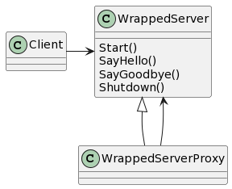

なお、正確には下記のようなクラス構造をProxyパターンと呼ぶことが多いが、 ここでは単純さを優先した。

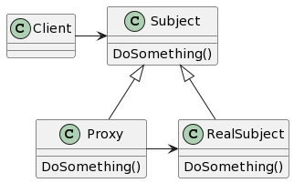

## Strategy

関数f(args)の振る舞いが、

- 全体の制御
- 部分的な振る舞い(何らかの条件を探す等)

に分けられるような場合、関数fを

- 「全体の制御」を行う関数g
- 「部分的な振る舞い」を規定するStrategyオブジェクト(関数へのポインタ、関数オブジェクト、ラムダ式)

に分割し、下記のように、Strategyオブジェクトをgの引数として外部から渡せるようにしたパターンである (std::sort()のようなパターン)。

```cpp
    g(args, Strategyオブジェクト)
```

Strategyオブジェクトにいろいろなバリエーションがある場合、このパターンを使うと良い。 なお、このパターンの対象はクラスになる場合もある。

「ディレクトリをリカーシブに追跡し、引数で指定された属性にマッチしたファイルの一覧を返す関数」 を開発することを要求されたとする。

まずは、拡張性のない実装例を示す。

```cpp
    // @@@ example/design_pattern/find_files_old_style.h 4

    /// @enum FindCondition
    /// find_files_recursivelyの条件
    enum class FindCondition {
        File,              ///< pathがファイル
        Dir,               ///< pathがディレクトリ
        FileNameHeadIs_f,  ///< pathがファイル且つ、そのファイル名の先頭が"f"
    };
```

```cpp
    // @@@ example/design_pattern/find_files_old_style.cpp 9

    /// @fn std::vector<std::string> find_files_recursively(std::string const& path,
    ///                                                     FindCondition condition)
    /// @brief 条件にマッチしたファイルをリカーシブに探して返す
    /// @param path      リカーシブにディレクトリをたどるための起点となるパス
    /// @param condition どのようなファイルかを指定する
    /// @return 条件にマッチしたファイルをstd::vector<std::string>で返す
    std::vector<std::string> find_files_recursively(std::string const& path, FindCondition condition)
    {
        auto files = std::vector<fs::path>{};

        // recursive_directory_iteratorはファイルシステム依存するため、その依存を排除する他の処理
        std::copy(fs::recursive_directory_iterator{path}, fs::recursive_directory_iterator{},
                  std::back_inserter(files));

        std::sort(files.begin(), files.end());

        auto ret = std::vector<std::string>{};

        std::for_each(files.begin(), files.end(), [&](fs::path const& p) noexcept {
            auto is_match = false;

            switch (condition) {
            case FindCondition::File:
                if (fs::is_regular_file(p)) {
                    is_match = true;
                }
                break;
            case FindCondition::Dir:
                if (fs::is_directory(p)) {
                    is_match = true;
                }
                break;
                ...
            }

            if (is_match) {
                ret.emplace_back(p.generic_string());
            }
        });

        return ret;
    }
```

```cpp
    // @@@ example/design_pattern/find_files_ut.cpp 29

    TEST(Strategy, old_style)
    {
        assure_test_files_exist();  // test用のファイルがあることの確認

        auto const files_actual = find_files_recursively(test_dir, FindCondition::File);
        auto const files_expect = sort(std::vector{
            test_dir + "dir0/file2",
            test_dir + "dir0/gile3",
            test_dir + "dir1/dir2/file4",
            test_dir + "file0",
            test_dir + "gile1"
        });
        ASSERT_EQ(files_expect, files_actual);

        auto const dirs_actual = find_files_recursively(test_dir, FindCondition::Dir);
        auto const dirs_expect = sort(std::vector{
            test_dir + "dir0",
            test_dir + "dir1",
            test_dir + "dir1/dir2"
        });
        ASSERT_EQ(dirs_expect, dirs_actual);

        auto const f_actual = find_files_recursively(test_dir, FindCondition::FileNameHeadIs_f);
        auto const f_expect = sort(std::vector{
            test_dir + "dir0/file2",
            test_dir + "dir1/dir2/file4",
            test_dir + "file0"
        });
        ASSERT_EQ(f_expect, f_actual);
    }
```

この関数は、見つかったファイルが「引数で指定された属性」にマッチするかどうかを検査する。 検査は、「引数で指定された属性」に対するswitch文によって行われる。 これにより、この関数は「引数で指定された属性」の変更に強く影響を受ける。

下記は、この関数にStrategyパターンを適用したものである。

```cpp
    // @@@ example/design_pattern/find_files_strategy.h 7

    /// @typedef find_condition
    /// @brief find_files_recursively仮引数conditionの型(関数オブジェクトの型)
    using find_condition = std::function<bool(std::filesystem::path const&)>;

    // Strategyパターン
    /// @fn std::vector<std::string> find_files_recursively(std::string const& path,
    ///                                                     find_condition     condition);
    /// @brief 条件にマッチしたファイルをリカーシブに探索して返す
    /// @param path      リカーシブにディレクトリを辿るための起点となるパス
    /// @param condition 探索するファイルの条件
    /// @return 条件にマッチしたファイルをstd::vector<std::string>で返す
    extern std::vector<std::string> find_files_recursively(std::string const& path,
                                                           find_condition     condition);
```

```cpp
    // @@@ example/design_pattern/find_files_strategy.cpp 6

    std::vector<std::string> find_files_recursively(std::string const& path, find_condition condition)
    {
        namespace fs = std::filesystem;

        auto files = std::vector<fs::path>{};

        // recursive_directory_iteratorはファイルシステム依存するため、その依存を排除する他の処理
        std::copy(fs::recursive_directory_iterator{path}, fs::recursive_directory_iterator{},
                  std::back_inserter(files));

        std::sort(files.begin(), files.end());

        auto ret = std::vector<std::string>{};

        std::for_each(files.cbegin(), files.cend(), [&](fs::path const& p) {
            if (condition(p)) {
                ret.emplace_back(p.generic_string());
            }
        });

        return ret;
    }
```

```cpp
    // @@@ example/design_pattern/find_files_ut.cpp 69

    TEST(Strategy, strategy_lamda)
    {
        namespace fs = std::filesystem;

        assure_test_files_exist();  // test用のファイルがあることの確認

        // ラムダ式で実装
        auto const files_actual = find_files_recursively(
            test_dir, [](fs::path const& p) noexcept { return fs::is_regular_file(p); });

        auto const files_expect = sort(std::vector{
            test_dir + "dir0/file2",
            test_dir + "dir0/gile3",
            test_dir + "dir1/dir2/file4",
            test_dir + "file0",
            test_dir + "gile1"
        });
        ASSERT_EQ(files_expect, files_actual);

        auto const dirs_actual = find_files_recursively(
            test_dir, [](fs::path const& p) noexcept { return fs::is_directory(p); });
        auto const dirs_expect = sort(std::vector{
            test_dir + "dir0",
            test_dir + "dir1",
            test_dir + "dir1/dir2"
        });
        ASSERT_EQ(dirs_expect, dirs_actual);

        auto const f_actual = find_files_recursively(test_dir, [](fs::path const& p) noexcept {
            return p.filename().generic_string()[0] == 'f';
        });

        auto const f_expect = sort(std::vector{
            test_dir + "dir0/file2",
            test_dir + "dir1/dir2/file4",
            test_dir + "file0"
        });
        ASSERT_EQ(f_expect, f_actual);
    }

    /// @fn bool condition_func(std::filesystem::path const& path)
    /// @brief find_files_recursivelyの第2仮引数に渡すためのファイル属性を決める関数
    bool condition_func(std::filesystem::path const& path)
    {
        return path.filename().generic_string().at(0) == 'f';
    }

    TEST(Strategy, strategy_func_pointer)
    {
        assure_test_files_exist();  // test用のファイルがあることの確認

        // FindCondition::FileNameHeadIs_fで行ったことを関数ポインタで実装。
        auto const f_actual = find_files_recursively(test_dir, condition_func);
        auto const f_expect = sort(std::vector{
            test_dir + "dir0/file2",
            test_dir + "dir1/dir2/file4",
            test_dir + "file0"
        });
        ASSERT_EQ(f_expect, f_actual);
    }

    /// @class ConditionFunctor
    /// @brief
    ///  find_files_recursivelyの第2仮引数に渡すためのファイル属性を決める関数オブジェクトクラス。
    ///  検索条件に状態が必要な場合、関数オブジェクトを使うとよい。
    class ConditionFunctor {
    public:
        ConditionFunctor()  = default;
        ~ConditionFunctor() = default;

        /// @fn bool operator()(std::filesystem::path const& path)
        /// @brief 先頭が'f'のファイルを最大2つまで探す
        bool operator()(std::filesystem::path const& path)
        {
            if (path.filename().generic_string().at(0) != 'f') {
                return false;
            }

            return ++count_ < 3;
        }

    private:
        int32_t count_{0};
    };

    TEST(Strategy, strategy_func_obj)
    {
        // 条件に状態が必要な場合(この例では最大2つまでを判断するのに状態が必要)、
        // 関数ポインタより、ファンクタの方が便利。
        auto const f_actual = find_files_recursively(test_dir, ConditionFunctor{});
        auto const f_expect = sort(std::vector{
            test_dir + "dir0/file2",
            test_dir + "dir1/dir2/file4",
        });
        ASSERT_EQ(f_expect, f_actual);
    }
```

捜査対象のファイル属性の指定をfind_files_recursively()の外に出しため、 その属性の追加に対して「オープン・クローズドの原則(OCP)」に対応した構造となった。

なお、上記find_files_recursivelyの第2パラメータをテンプレートパラメータとすることで、

```cpp
    // @@@ example/design_pattern/find_files_strategy.h 23

    template <typename F>  // Fはファンクタ
    auto find_files_recursively2(std::string const& path, F condition)
        -> std::enable_if_t<std::is_invocable_r_v<bool, F, std::filesystem::path const&>,
                            std::vector<std::string>>
    {
        namespace fs = std::filesystem;

        auto files = std::vector<fs::path>{};

        // recursive_directory_iteratorはファイルシステム依存するため、その依存を排除する他の処理
        std::copy(fs::recursive_directory_iterator{path}, fs::recursive_directory_iterator{},
                  std::back_inserter(files));

        std::sort(files.begin(), files.end());

        auto ret = std::vector<std::string>{};

        std::for_each(files.cbegin(), files.cend(), [&](fs::path const& p) {
            if (condition(p)) {
                ret.emplace_back(p.generic_string());
            }
        });

        return ret;
    }
```

のように書くこともできる。

次に示すのは、このパターンを使用して、プリプロセッサ命令を排除するリファクタリングの例である。

まずは、出荷仕分け向けのプリプロセッサ命令をロジックの内部に記述している問題のあるコードを示す。 このようなオールドスタイルなコードは様々な開発阻害要因になるため、避けるべきである。

```cpp
    // @@@ example/design_pattern/strategy_shipping_ut.cpp 11

    class X {
    public:
        X() = default;

        int32_t DoSomething()
        {
            int32_t ret{0};

    #if SHIPPING == SHIP_TO_JAPAN
            // 日本向けの何らかの処理
    #elif SHIPPING == SHIP_TO_US
            // US向けの何らかの処理
    #elif SHIPPING == SHIP_TO_JAPAN
            // EU向けの何らかの処理
    #else
    #error "SHIPPING must be defined"
    #endif
            return ret;
        }

    private:
        // 何らかの宣言
    };
```

```cpp
    // @@@ example/design_pattern/strategy_shipping_ut.cpp 43

    X x;

    x.DoSomething();
```

このコードは、Strategyを使用し以下のようにすることで、改善することができる。

```cpp
    // @@@ example/design_pattern/strategy_shipping_ut.cpp 56

    class ShippingOp {
    public:
        virtual int32_t DoSomething() = 0;
        virtual ~ShippingOp()         = default;
    };

    class X {
    public:
        X() = default;

        int32_t DoSomething(ShippingOp& shipping)
        {
            int32_t ret = shipping.DoSomething();

            // 何らかの処理

            return ret;
        }

    private:
        // 何らかの宣言
    };
```

```cpp
    // @@@ example/design_pattern/strategy_shipping_ut.cpp 81

    class ShippingOp_Japan : public ShippingOp {
    public:
        ShippingOp_Japan();
        int32_t DoSomething() override;
        ~ShippingOp_Japan() override;

    private:
        // 何らかの宣言
    };
```

```cpp
    // @@@ example/design_pattern/strategy_shipping_ut.cpp 100

    X                x;
    ShippingOp_Japan sj;

    x.DoSomething(sj);
```

あるいは、DI(dependency injection)と組み合わせて、下記のような改善も有用である。

```cpp
    // @@@ example/design_pattern/strategy_shipping_ut.cpp 112

    class ShippingOp {
    public:
        virtual int32_t DoSomething() = 0;
        virtual ~ShippingOp()         = default;
    };

    class X {
    public:
        explicit X(std::unique_ptr<ShippingOp> shipping) : shipping_{std::move(shipping)} {}

        int32_t DoSomething()
        {
            int32_t ret = shipping_->DoSomething();

            // 何らかの処理

            return ret;
        }

    private:
        std::unique_ptr<ShippingOp> shipping_;
        // 何らかの宣言
    };
```

```cpp
    // @@@ example/design_pattern/strategy_shipping_ut.cpp 138

    class ShippingOp_Japan : public ShippingOp {
    public:
        ShippingOp_Japan();
        int32_t DoSomething() override;
        ~ShippingOp_Japan() override;

    private:
        // 何らかの宣言
    };
```

```cpp
    // @@@ example/design_pattern/strategy_shipping_ut.cpp 157

    X x{std::unique_ptr<ShippingOp>(new ShippingOp_Japan)};

    x.DoSomething();
```

## Visitor

このパターンは、クラス構造とそれに関連するアルゴリズムを分離するためのものである。

最初に 「クラス構造とそれに関連するアルゴリズムは分離できているが、 それ以前にオブジェクト指向の原則に反している」 例を示す。

```cpp
    // @@@ example/design_pattern/visitor.cpp 42

    /// @class FileEntity
    /// @brief
    ///  ファイルシステムの構成物(ファイル、ディレクトリ等)を表すクラスの基底クラス
    class FileEntity {
    public:
        explicit FileEntity(std::string pathname) : pathname_{std::move(pathname)} {}
        virtual ~FileEntity() {}
        std::string const& Pathname() const { return pathname_; }

        ...

    private:
        std::string const pathname_;
    };

    class File final : public FileEntity {
        ...
    };

    class Dir final : public FileEntity {
        ...
    };

    class OtherEntity final : public FileEntity {
        ...
    };

    class Printer {
    public:
        static void PrintPathname1(FileEntity const& file_entity)
        {
            if (typeid(File) == typeid(file_entity)) {
                std::cout << file_entity.Pathname();
            }
            else if (typeid(Dir) == typeid(file_entity)) {
                std::cout << file_entity.Pathname() + "/";
            }
            else if (typeid(OtherEntity) == typeid(file_entity)) {
                std::cout << file_entity.Pathname() + "(o1)";
            }
            else {
                assert(false);
            }
        }

        static void PrintPathname2(FileEntity const& file_entity)
        {
            if (typeid(File) == typeid(file_entity)) {
                std::cout << file_entity.Pathname();
            }
            else if (typeid(Dir) == typeid(file_entity)) {
                std::cout << find_files(file_entity.Pathname());
            }
            else if (typeid(OtherEntity) == typeid(file_entity)) {
                std::cout << file_entity.Pathname() + "(o2)";
            }
            else {
                assert(false);
            }
        }
    };
```

下記クラス図からもわかる通り、ポリモーフィズムに反したこのような構造は複雑な依存関係を作り出す。 このアンチパターンにより同型の条件文が2度出てきてしまうため、 Printerのアルゴリズム関数が増えれば、この繰り返しはそれに比例して増える。 またFileEntityの派生が増えれば、それら条件文はすべて影響を受ける。 このようなソースコードは、このようにして等比級数的に複雑化する。

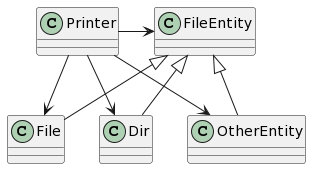

これをポリモーフィズムの導入で解決した例を示す。

```cpp
    // @@@ example/design_pattern/visitor.cpp 143

    class FileEntity {
    public:
        explicit FileEntity(std::string pathname) : pathname_{std::move(pathname)} {}
        ...
        virtual void PrintPathname1() const = 0;
        virtual void PrintPathname2() const = 0;

    private:
        std::string const pathname_;
    };

    class File final : public FileEntity {
    public:
        ...
        virtual void PrintPathname1() const override { std::cout << Pathname(); }
        virtual void PrintPathname2() const override { std::cout << Pathname(); }
    };

    class Dir final : public FileEntity {
    public:
        ...
        virtual void PrintPathname1() const override { std::cout << Pathname() + "/"; }
        virtual void PrintPathname2() const override { std::cout << find_files(Pathname()); }
    };

    class OtherEntity final : public FileEntity {
    public:
        ...
        virtual void PrintPathname1() const override { std::cout << Pathname() + "(o1)"; }
        virtual void PrintPathname2() const override { std::cout << Pathname() + "(o2)"; }
    };

    class Printer {
    public:
        static void PrintPathname1(FileEntity const& file_entity) { file_entity.PrintPathname1(); }
        static void PrintPathname2(FileEntity const& file_entity) { file_entity.PrintPathname2(); }
    };
```

上記例では、PrinterのアルゴリズムをFileEntityの各派生クラスのメンバ関数で実装することで、 Printerの各関数は単純化された。

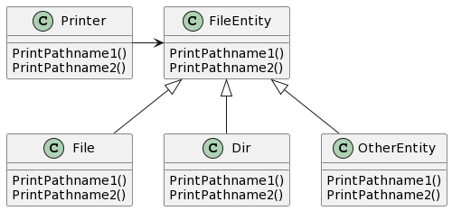

これはポリモーフィズムによるリファクタリングの良い例と言えるが、 SRP(「単一責任の原則(SRP)」)に反するため、 Printerの関数が増えるたびにPrintPathname1、 PrintPathname2のようなFileEntityのインターフェースが増えてしまう。

このようなインターフェースの肥大化に対処するパターンがVisitorである。

上記例にVisitorを適用してリファクタリングした例を示す。

```cpp
    // @@@ example/design_pattern/visitor.h 9

    class FileEntityVisitor {
    public:
        virtual void Visit(File const&)        = 0;
        virtual void Visit(Dir const&)         = 0;
        virtual void Visit(OtherEntity const&) = 0;
        ...
    };

    class FileEntity {
    public:
        explicit FileEntity(std::string pathname) : pathname_{std::move(pathname)} {}
        ...
        std::string const& Pathname() const { return pathname_; }

        virtual void Accept(FileEntityVisitor&) const = 0;  // Acceptの仕様は安定しているので
                                                            // NVIは使わない。
    private:
        std::string const pathname_;
    };

    class File final : public FileEntity {
    public:
        using FileEntity::FileEntity;
        virtual void Accept(FileEntityVisitor& visitor) const override { visitor.Visit(*this); }
    };

    class Dir final : public FileEntity {
    public:
        using FileEntity::FileEntity;
        virtual void Accept(FileEntityVisitor& visitor) const override { visitor.Visit(*this); }
    };

    class OtherEntity final : public FileEntity {
    public:
        using FileEntity::FileEntity;
        virtual void Accept(FileEntityVisitor& visitor) const override { visitor.Visit(*this); }
    };

    class PathnamePrinter1 final : public FileEntityVisitor {
    public:
        virtual void Visit(File const&) override;
        virtual void Visit(Dir const&) override;
        virtual void Visit(OtherEntity const&) override;
    };

    class PathnamePrinter2 final : public FileEntityVisitor {
    public:
        virtual void Visit(File const&) override;
        virtual void Visit(Dir const&) override;
        virtual void Visit(OtherEntity const&) override;
    };
```

```cpp
    // @@@ example/design_pattern/visitor.cpp 219

    void PathnamePrinter1::Visit(File const& file) { std::cout << file.Pathname(); }
    void PathnamePrinter1::Visit(Dir const& dir) { std::cout << dir.Pathname() + "/"; }
    void PathnamePrinter1::Visit(OtherEntity const& other) { std::cout << other.Pathname() + "(o1)"; }

    void PathnamePrinter2::Visit(File const& file) { std::cout << file.Pathname(); }
    void PathnamePrinter2::Visit(Dir const& dir) { std::cout << find_files(dir.Pathname()); }
    void PathnamePrinter2::Visit(OtherEntity const& other) { std::cout << other.Pathname() + "(o2)"; }

    class Printer {
    public:
        static void PrintPathname1(FileEntity const& file_entity)
        {
            auto visitor = PathnamePrinter1{};

            file_entity.Accept(visitor);
        }

        static void PrintPathname2(FileEntity const& file_entity)
        {
            auto visitor = PathnamePrinter2{};

            file_entity.Accept(visitor);
        }
    };
```

上記クラスの関係は下記のようになる。

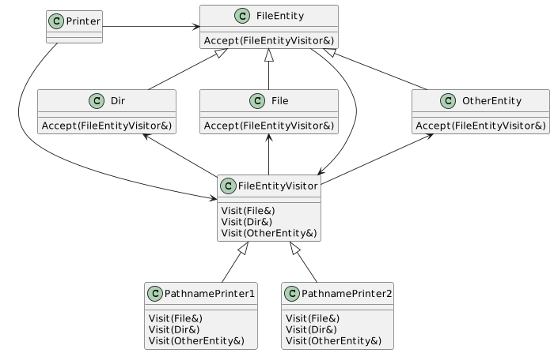

このリファクタリングには、

- FileEntityのインターフェースを小さくできる
- FileEntityVisitorから派生できるアルゴリズムについては、 FileEntityのインターフェースに影響を与えずに追加できる (「オープン・クローズドの原則(OCP)」参照)

という利点がある。 一方で、この程度の複雑さの(単純な)例では、Visitorの適用によって以前よりも構造が複雑になり、 改悪してしまった可能性があるため、デザインパターンを使用する場合には注意が必要である。

なお、上記の抜粋である下記コード

```cpp
    // @@@ example/design_pattern/visitor.h 39

    virtual void Accept(FileEntityVisitor& visitor) const override { visitor.Visit(*this); }
```

はコードクローンだが、thisの型が違うため、 各Acceptが呼び出すFileEntityVisitor::Visit()も異り、単純に統一することはできない。 これを改めるためには、「CRTP(curiously recurring template pattern)」が必要になる。

次に示すソースコードはVisitorとは関係がないが、 FileEntityVisitorから派生するクラスを下記クラス図が示すように改善することで、 単体テストが容易になる例である(「DI(dependency injection)」参照)。

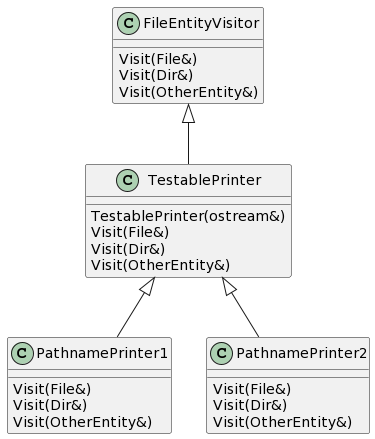

```cpp
    // @@@ example/design_pattern/visitor.h 72

    class TestablePrinter : public FileEntityVisitor {
    public:
        explicit TestablePrinter(std::ostream& os) : ostream_{os} {}

    protected:
        std::ostream& ostream_;
    };

    class TestablePathnamePrinter1 final : public TestablePrinter {
    public:
        explicit TestablePathnamePrinter1(std::ostream& os) : TestablePrinter{os} {}
        virtual void Visit(File const& file) override;
        virtual void Visit(Dir const& dir) override;
        virtual void Visit(OtherEntity const& other) override;
    };

    class TestablePathnamePrinter2 final : public TestablePrinter {
    public:
        explicit TestablePathnamePrinter2(std::ostream& os) : TestablePrinter{os} {}
        virtual void Visit(File const& file) override;
        virtual void Visit(Dir const& dir) override;
        virtual void Visit(OtherEntity const& other) override;
    };
```

```cpp
    // @@@ example/design_pattern/visitor.cpp 246

    void TestablePathnamePrinter1::Visit(File const& file) { ostream_ << file.Pathname(); }
    void TestablePathnamePrinter1::Visit(Dir const& dir) { ostream_ << dir.Pathname() + "/"; }
    void TestablePathnamePrinter1::Visit(OtherEntity const& other)
    {
        ostream_ << other.Pathname() + "(o1)";
    }

    void TestablePathnamePrinter2::Visit(File const& file) { ostream_ << file.Pathname(); }

    void TestablePathnamePrinter2::Visit(Dir const& dir) { ostream_ << find_files(dir.Pathname()); }

    void TestablePathnamePrinter2::Visit(OtherEntity const& other)
    {
        ostream_ << other.Pathname() + "(o2)";
    }
```

```cpp
    // @@@ example/design_pattern/visitor_ut.cpp 28

    TEST(Visitor, testable_visitor)
    {
        auto oss = std::ostringstream{};

        // 出力をキャプチャするため、std::coutに代えてossを使う
        auto visitor1 = TestablePathnamePrinter1{oss};
        auto visitor2 = TestablePathnamePrinter2{oss};

        auto file = File{"visitor.cpp"};
        {
            file.Accept(visitor1);
            ASSERT_EQ("visitor.cpp", oss.str());
            oss = {};
        }
        {
            file.Accept(visitor2);
            ASSERT_EQ("visitor.cpp", oss.str());
            oss = {};
        }

        auto dir = Dir{"find_files_ut_dir/dir0"};
        {
            dir.Accept(visitor1);
            ASSERT_EQ("find_files_ut_dir/dir0/", oss.str());
            oss = {};
        }
        {
            dir.Accept(visitor2);
            ASSERT_EQ("find_files_ut_dir/dir0/file2,find_files_ut_dir/dir0/gile3", oss.str());
            oss = {};
        }
    }
```

## CRTP(curiously recurring template pattern)

CRTPとは、

```cpp
    // @@@ example/design_pattern/crtp_ut.cpp 8

    template <typename T>
    class Base {
        ...
    };

    class Derived : public Base<Derived> {
        ...
    };
```

のようなテンプレートによる再帰構造を用いて、静的ポリモーフィズムを実現するためのパターンである。

このパターンを用いて、「Visitor」のFileEntityの3つの派生クラスが持つコードクローン

```cpp
    // @@@ example/design_pattern/visitor.h 39

    virtual void Accept(FileEntityVisitor& visitor) const override { visitor.Visit(*this); }
```

を解消した例を以下に示す。

```cpp
    // @@@ example/design_pattern/crtp.h 31

    class FileEntity {  // VisitorのFileEntityと同じ
    public:
        explicit FileEntity(std::string&& pathname) : pathname_{std::move(pathname)} {}
        virtual ~FileEntity() {}
        std::string const& Pathname() const { return pathname_; }

        virtual void Accept(FileEntityVisitor&) const = 0;  // Acceptの仕様は安定しているので
                                                            // NVIは使わない。
    private:
        std::string const pathname_;
    };

    template <typename T>
    class AcceptableFileEntity : public FileEntity {  // CRTP
    public:
        virtual void Accept(FileEntityVisitor& visitor) const override
        {
            visitor.Visit(*static_cast<T const*>(this));
        }

    private:
        // T : public AcceptableFileEntity<T> { ... };
        // 以外の使い方をコンパイルエラーにする
        AcceptableFileEntity(std::string&& pathname) : FileEntity{std::move(pathname)} {}
        friend T;
    };

    class File final : public AcceptableFileEntity<File> {  // CRTPでクローンを解消
    public:
        File(std::string pathname) : AcceptableFileEntity{std::move(pathname)} {}
    };

    class Dir final : public AcceptableFileEntity<Dir> {  // CRTPでクローンを解消
    public:
        Dir(std::string pathname) : AcceptableFileEntity{std::move(pathname)} {}
    };

    class OtherEntity final : public AcceptableFileEntity<OtherEntity> {  // CRTPでクローンを解消
    public:
        OtherEntity(std::string pathname) : AcceptableFileEntity{std::move(pathname)} {}
    };
```

## Observer

Observerは、クラスSubjectと複数のクラスObserverN(N = 0, 1, 2 …)があり、 この関係が下記の条件を満たさなければならない場合に使用されるパターンである。

- ObserverNオブジェクトはSubjectオブジェクトが変更された際、その変更通知を受け取る。
- SubjectはObserverNへ依存してはならない。

GUIアプリケーションをMVCで実装する場合のModelがSubjectであり、 ViewがObserverNである。

まずは、このパターンを使用しない実装例を示す。

```cpp
    // @@@ example/design_pattern/observer_ng.h 6

    /// @class ObserberNG_N
    /// @brief SubjectNGからの変更通知をUpdate()で受け取る。
    ///        Observerパターンを使用しない例。
    class ObserverNG_0 {
    public:
        ObserverNG_0() = default;

        virtual void Update(SubjectNG const& subject)  // テストのためにvirtual
        {
            // 何らかの処理
        }

        virtual ~ObserverNG_0() = default;
        // 何らかの定義、宣言
    };

    class ObserverNG_1 {
    public:
        ...
    };

    class ObserverNG_2 {
    public:
        ...
    };
```

```cpp
    // @@@ example/design_pattern/observer_ng.cpp 6

    void ObserverNG_1::Update(SubjectNG const& subject)
    {
        ...
    }

    void ObserverNG_2::Update(SubjectNG const& subject)
    {
        ...
    }
```

```cpp
    // @@@ example/design_pattern/subject_ng.h 9

    /// @class SubjectNG
    /// @brief 監視されるクラス。SetNumでの状態変更をObserverNG_Nに通知する。
    ///        Observerパターンを使用しない例。
    class SubjectNG final {
    public:
        explicit SubjectNG(ObserverNG_0& ng_0, ObserverNG_1& ng_1, ObserverNG_2& ng_2) noexcept
            : num_{0}, ng_0_{ng_0}, ng_1_{ng_1}, ng_2_{ng_2}
        {
        }

        void SetNum(uint32_t num);
        ...
    };
```

```cpp
    // @@@ example/design_pattern/subject_ng.cpp 4

    void SubjectNG::SetNum(uint32_t num)
    {
        if (num_ == num) {
            return;
        }

        num_ = num;

        notify();  // subjectが変更されたことをobserverへ通知
    }

    void SubjectNG::notify()
    {
        ng_0_.Update(*this);
        ng_1_.Update(*this);
        ng_2_.Update(*this);
    }
```

```cpp
    // @@@ example/design_pattern/observer_ut.cpp 15

    struct ObserverNG_0_Test : ObserverNG_0 {  // テスト用クラス
        virtual void Update(SubjectNG const& subject) final
        {
            ++call_count;
            num = subject.GetNum();
        }

        uint32_t                call_count{0};
        std::optional<uint32_t> num{};
    };

    auto ng0 = ObserverNG_0_Test{};
    auto ng1 = ObserverNG_1{};
    auto ng2 = ObserverNG_2{};

    auto subject = SubjectNG{ng0, ng1, ng2};

    ASSERT_EQ(0, ng0.call_count);  // まだ何もしていない
    ASSERT_FALSE(ng0.num);

    subject.SetNum(1);
    subject.SetNum(2);

    ASSERT_EQ(2, ng0.call_count);
    ASSERT_EQ(2, *ng0.num);

    subject.SetNum(2);  // 同じ値をセットしたため、Updateは呼ばれないはず
    ASSERT_EQ(2, ng0.call_count);
    ASSERT_EQ(2, *ng0.num);
```

上記実装例のクラス図を下記する。 これを見ればわかるように、クラスSubjectNGとクラスObserverNG_Nは相互依存しており、機能追加、 修正が難しいだけではなく、この図の通りにパッケージを分割した場合 (パッケージがライブラリとなると前提）、リンクすら難しくなる。

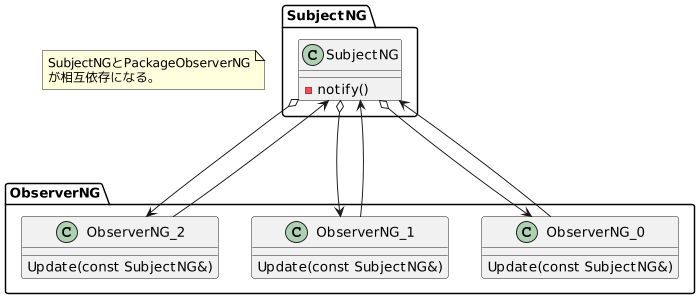

このようなクラス間の依存関係は下記のようにファイル間の依存関係に反映される。 このような相互依存は、差分ビルドの長時間化等の問題も引き起こす。

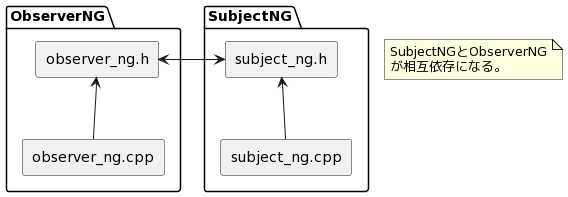

次に、上記にObserverパターンを適用した実装例 (Subjectを抽象クラスにすることもあるが、下記例ではSubjectを具象クラスにしている)を示す。

```cpp
    // @@@ example/design_pattern/observer_ok.h 3

    /// @class ObserverOK_0
    /// @brief SubjectOKからの変更通知をUpdate()で受け取る。
    ///        Observerパターンの使用例。
    class ObserverOK_0 : public Observer {
        ...
    private:
        virtual void update(SubjectOK const& subject) override;
    };

    class ObserverOK_1 : public Observer {
        ...
    private:
        virtual void update(SubjectOK const& subject) override;
    };

    class ObserverOK_2 : public Observer {
        ...
    private:
        virtual void update(SubjectOK const& subject) override;
    };
```

```cpp
    // @@@ example/design_pattern/observer_ok.cpp 5

    void ObserverOK_0::update(SubjectOK const& subject)
    {
        ...
    }

    void ObserverOK_1::update(SubjectOK const& subject)
    {
        ...
    }

    void ObserverOK_2::update(SubjectOK const& subject)
    {
        ...
    }
```

```cpp
    // @@@ example/design_pattern/subject_ok.h 8

    /// @class SubjectOK
    /// @brief 監視されるクラス。SetNumでの状態変更をObserverOK_Nに通知する。
    ///        Observerパターンの使用例。
    class SubjectOK final {
    public:
        SubjectOK() : observers_{}, num_{0} {}

        void SetNum(uint32_t num)
        {
            if (num_ == num) {
                return;
            }

            num_ = num;

            notify();  // subjectが変更されたことをobserverへ通知
        }

        void     Attach(Observer& observer);           // Observerの登録
        void     Detach(Observer& observer) noexcept;  // Observerの登録解除
        uint32_t GetNum() const noexcept { return num_; }

    private:
        void notify() const;

        std::list<Observer*> observers_;
        ...
    };

    /// @class Observer
    /// @brief SubjectOKを監視するクラスの基底クラス
    class Observer {
    public:
        Observer() = default;
        void Update(SubjectOK const& subject) { update(subject); }

        ...
    private:
        virtual void update(SubjectOK const& subject) = 0;
        ...
    };
```

```cpp
    // @@@ example/design_pattern/subject_ok.cpp 3

    void SubjectOK::Attach(Observer& observer_to_attach) { observers_.push_back(&observer_to_attach); }

    void SubjectOK::Detach(Observer& observer_to_detach) noexcept
    {
        observers_.remove_if(
            [&observer_to_detach](Observer* observer) { return &observer_to_detach == observer; });
    }

    void SubjectOK::notify() const
    {
        for (auto observer : observers_) {
            observer->Update(*this);
        }
    }
```

```cpp
    // @@@ example/design_pattern/observer_ut.cpp 51

    struct ObserverOK_Test : Observer {  // テスト用クラス
        virtual void update(SubjectOK const& subject) final
        {
            ++call_count;
            num = subject.GetNum();
        }

        uint32_t                call_count{0};
        std::optional<uint32_t> num{};
    };

    auto ok0 = ObserverOK_Test{};
    auto ok1 = ObserverOK_1{};
    auto ok2 = ObserverOK_2{};

    auto subject = SubjectOK{};

    subject.Attach(ok0);
    subject.Attach(ok1);
    subject.Attach(ok2);

    ASSERT_EQ(0, ok0.call_count);  // まだ何もしていない
    ASSERT_FALSE(ok0.num);

    subject.SetNum(1);
    subject.SetNum(2);

    ASSERT_EQ(2, ok0.call_count);
    ASSERT_EQ(2, *ok0.num);

    subject.SetNum(2);  // 同じ値をセットしたため、Updateは呼ばれないはず
    ASSERT_EQ(2, ok0.call_count);
    ASSERT_EQ(2, *ok0.num);
```

上記実装例のクラス図を下記する。 Observerパターンを使用しない例と比べると、 クラスSubjectOKとクラスObserverOK_Nとの相互依存が消えたことがわかる。

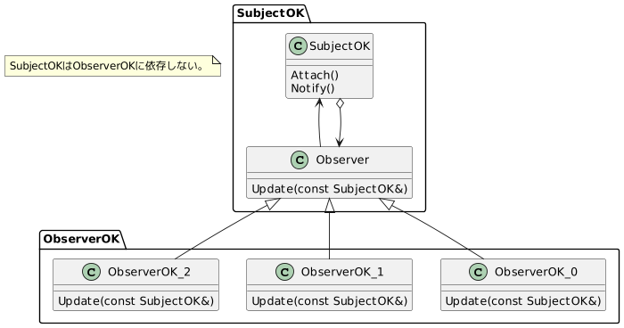

最後に、上記のファイルの依存関係を示す。 ファイル(パッケージ)の依存関係においてもSubjectOKはObserverOKに依存していないことがわかる (MVCに置き換えると、ModelはViewに依存していない状態であるといえる)。

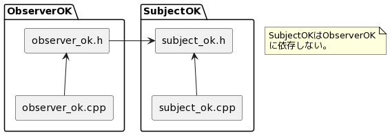

## MVC

MVCはデザインパターンと言うよりもアーキテクチャパターンである。 一般にGUIアプリケーションのアーキテクチャに使用されるが、 外部からの非同期要求を処理するアプリケーションのアーキテクチャにも相性が良い。

MVCのそれぞれのアルファベットの意味は、下記テーブルの通りである。

|  | MVC | 主な役割 |
| --- | --- | --- |
| M | Model | ビジネスロジックの処理 |
| V | View | UIへの出力 |
| C | Controller | 入力をModelへ送信 |

下記はMVCの概念モデルである(矢印は制御の流れであって、依存関係ではない)。

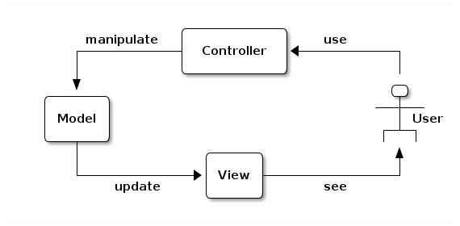

制御の流れは、

1. ユーザの入力に応じてControllerのメソッドが呼び出される。
2. Controllerのメソッドは、ユーザの入力に応じた引数とともにModelのメソッドを呼び出す。
3. Modelは、それに対応するビジネスロジック等の処理を(通常、非同期に)行い、 自分自身の状態を変える(変わらないこともある)。
4. Modelの状態変化は、そのModelのオブザーバーとして登録されているViewに通知される。
5. Viewは関連するデータをModelから取得し、それを出力(UIに表示)する。

ViewはModelのObserverであるため、ModelはViewへ依存しない。 多々あるMVC派生パターンすべてで、そのような依存関係は存在しない (具体的なパターンの選択はプロジェクトで使用するGUIフレームワークに強く依存する)。

そのようにする理由は下記の通りで、極めて重要な規則である。

## Cでのクラス表現

このドキュメントは、C++でのソフトウェア開発を前提としているため、 ここで示したコードもC++で書いているが、

- 何らかの事情でCを使わざるを得ないプログラマがデザインパターンを使用できるようにする
- クラスの理解が曖昧なC++プログラマの理解を助ける(「クラスのレイアウト」参照)

ような目的のためにCでのクラスの実現方法を例示する。

下記のような基底クラスPointとその派生クラスPoint3Dがあった場合、

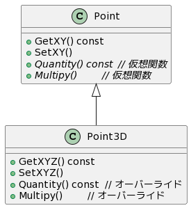

C++では、Pointのコードは下記のように表すことが一般的である。

```cpp
    // @@@ example/design_pattern/class_ut.cpp 7

    class Point {
    public:
        explicit Point(int x, int y) noexcept : x_{x}, y_{y} {}
        virtual ~Point() = default;

        void SetXY(int x, int y) noexcept
        {
            x_ = x;
            y_ = y;
        }

        void GetXY(int& x, int& y) const noexcept
        {
            x = x_;
            y = y_;
        }

        virtual int Quantity() const noexcept { return x_ * y_; }

        virtual void Multipy(int m) noexcept
        {
            x_ *= m;
            y_ *= m;
        }

    private:
        int x_;
        int y_;
    };
```

この単体テストは、下記のようになる。

```cpp
    // @@@ example/design_pattern/class_ut.cpp 42

    Point a{1, 2};

    int x;
    int y;
    a.GetXY(x, y);
    ASSERT_EQ(x, 1);
    ASSERT_EQ(y, 2);

    a.SetXY(3, 4);

    a.GetXY(x, y);
    ASSERT_EQ(x, 3);
    ASSERT_EQ(y, 4);

    ASSERT_EQ(a.Quantity(), 12);

    a.Multipy(2);
    ASSERT_EQ(a.Quantity(), 48);
```

これをCで表した場合、下記のようになる。

```cpp
    // @@@ example/design_pattern/class_ut.cpp 124

    struct Point {
        int x;
        int y;

        int (*const Quantity)(Point const* self);
        void (*const Multipy)(Point* self, int m);
    };

    static int point_quantity(Point const* self) { return self->x * self->y; }

    static void point_multipy(Point* self, int m)
    {
        self->x *= m;
        self->y *= m;
    }

    Point Point_Construct(int x, int y)
    {
        Point ret = {x, y, point_quantity, point_multipy};  // C言語のつもり

        return ret;
    }

    void Point_SetXY(Point* self, int x, int y)
    {
        self->x = x;
        self->y = y;
    }

    void Point_GetXY(Point* self, int* x, int* y)
    {
        *x = self->x;
        *y = self->y;
    }
```

C++のメンバ関数はプログラマから見えない引数thisを持つ。 これを表したものが各関数の第1引数selfである。 また、ポリモーフィックな関数は関数ポインタで、 非ポリモーフィックな関数は通常の関数で表される。

この単体テストは、下記のようになる。

```cpp
    // @@@ example/design_pattern/class_ut.cpp 164

    Point a = Point_Construct(1, 2);

    int x;
    int y;

    Point_GetXY(&a, &x, &y);
    ASSERT_EQ(x, 1);
    ASSERT_EQ(y, 2);

    Point_SetXY(&a, 3, 4);

    Point_GetXY(&a, &x, &y);
    ASSERT_EQ(x, 3);
    ASSERT_EQ(y, 4);

    ASSERT_EQ(a.Quantity(&a), 12);

    a.Multipy(&a, 2);
    ASSERT_EQ(a.Quantity(&a), 48);
```

Pointから派生したクラスPoint3DのC++での実装を以下に示す。

```cpp
    // @@@ example/design_pattern/class_ut.cpp 65

    class Point3D : public Point {
    public:
        explicit Point3D(int x, int y, int z) noexcept : Point{x, y}, z_{z} {}

        void SetXYZ(int x, int y, int z) noexcept
        {
            SetXY(x, y);
            z_ = z;
        }

        void GetXYZ(int& x, int& y, int& z) const noexcept
        {
            GetXY(x, y);
            z = z_;
        }

        virtual int Quantity() const noexcept override { return Point::Quantity() * z_; }

        virtual void Multipy(int m) noexcept override
        {
            Point::Multipy(m);
            z_ *= m;
        }

    private:
        int z_;
    };
```

この単体テストは、下記のようになる。

```cpp
    // @@@ example/design_pattern/class_ut.cpp 98

    auto  a = Point3D{1, 2, 3};
    auto& b = a;

    auto x = int{};
    auto y = int{};
    b.GetXY(x, y);
    ASSERT_EQ(x, 1);
    ASSERT_EQ(y, 2);

    b.SetXY(3, 4);

    b.GetXY(x, y);
    ASSERT_EQ(x, 3);
    ASSERT_EQ(y, 4);

    ASSERT_EQ(b.Quantity(), 36);

    b.Multipy(2);
    ASSERT_EQ(b.Quantity(), 288);
```

これをCで実装したものが下記である。

```cpp
    // @@@ example/design_pattern/class_ut.cpp 188

    struct Point3D {
        Point point;
        int   z;
    };

    static int point3d_quantity(Point const* self)
    {
        Point3D const* self_derived = (Point3D const*)self;

        return point_quantity(self) * self_derived->z;
    }

    static void point3d_multipy(Point* self, int m)
    {
        point_multipy(self, m);

        Point3D* self_derived = (Point3D*)self;

        self_derived->z *= m;
    }

    Point3D Point3D_Construct(int x, int y, int z)
    {
        Point3D ret{{x, y, point3d_quantity, point3d_multipy}, z};

        return ret;
    }
```

この単体テストは、下記のようになる。

```cpp
    // @@@ example/design_pattern/class_ut.cpp 221

    Point3D a = Point3D_Construct(1, 2, 3);
    Point*  b = &a.point;

    int x;
    int y;

    Point_GetXY(b, &x, &y);
    ASSERT_EQ(x, 1);
    ASSERT_EQ(y, 2);

    Point_SetXY(b, 3, 4);

    Point_GetXY(b, &x, &y);
    ASSERT_EQ(x, 3);
    ASSERT_EQ(y, 4);

    ASSERT_EQ(b->Quantity(b), 36);

    b->Multipy(b, 2);
    ASSERT_EQ(b->Quantity(b), 288);
```

以上からわかる通り、Cでのクラス実装はC++のものに比べ、

- 記述が多い
- キャストを使わざるを得ない
- リファレンスが使えないため、NULLにならないハンドル変数をポインタにせざるを得ない

等といった問題があるため、「何らかの事情でC++が使えない」チームは、 なるべく早い時期にその障害を乗り越えることをお勧めする。

どうしてもその障害を超えられない場合は、 モダンC言語プログラミング が役に立つだろう。

# テンプレートメタプログラミング

本章でのテンプレートメタプログラミングとは、下記の2つを指す。

- ジェネリックプログラミング
- メタプログラミング

C++においては、この2つはテンプレートを用いたプログラミングとなる。

ジェネリックプログラミングとは、具体的なデータ型に依存しない抽象的プログラミングであり、 その代表的な成果物はSTLのコンテナやそれらを扱うアルゴリズム関数テンプレートである。

この利点は、

- i種の型
- j種のコンテナ
- k種のアルゴリズム

の開発を行うことを考えれば明らかである。

ジェネリックプログラミングが無ければ、コンテナの種類はi x j個必要になり、 それらに適用するアルゴリズム関数は、i x j x k個必要になる。 また、サポートする型の増加に伴いコンテナやアルゴリズム関数は指数関数的に増えて行く。 C言語のqsort()のように強引なキャストを使い、この増加をある程度食い止めることはできるが、 それによりコンパイラによる型チェックは無効化され、 静的な型付け言語を使うメリットの多くを失うことになる。

メタプログラミングとは、

- ジェネリックのサポート
- 実行時コードの最適化
- 関数やクラスを生成するコードのプログラミング

のような目的で行われるテンプレートプログラミングの総称である。

ジェネリックプログラミングとメタプログラミングに明確な境界はない、 また明確にしたところで大きなメリットはと思われるため、 本章では、これらをまとめた概念であるテンプレートメタプログラミングとして扱い、 ログ取得ライブラリやSTLを応用したNstdライブラリの実装を通して、 これらのテクニックや、使用上の注意点について解説する。

## ログ取得ライブラリの開発

ここではログ取得ライブラリの開発を行う。

### 要件

ログ取得ライブラリの要件は、

- ソースコードの場所とそこで指示されたオブジェクトの値を文字列で保持する
- 後からそれらを取り出せる

ことのみとする。下記はその文字列を取り出した例である。

```
    app/src/main.cpp: 96:Options
                         cmd       : GenPkg
                         in        :
                         out       :
                         recursive : true
                         src_as_pkg: false
        ...

    app/src/main.cpp: 51:start GenPkg

    file_utils/ut/path_utils.cpp: 38:1
    file_utils/ut/path_utils.cpp: 48:ut_data/app1
                         ut_data/app1/mod1
                         ut_data/app1/mod2

        ...

    app/src/main.cpp:100:Exit:0
```

単純化のためログの番号やタイムスタンプのサポートはしない。 また、実行速度や仕様メモリ量の制限等も本章の趣旨とは離れるため考慮しない。

### ログ取得ライブラリのインターフェース

ログ取得コードにより、コードクローンが増えたり、主なロジックの可読性が下がったのでは、 本末転倒であるため、下記のようにワンライナーで記述できるべきだろう。

```cpp
    LOGGER("start GenPkg", objA, objB, objC);
```

また、要件で述べた通り、ソースコード位置を特定できなければならないため、 上記LOGGERは下記のような関数型マクロにならざるを得ない。

```cpp
    #define LOGGER(...) CppLoggerFunc(__FILE__, __LINE__, __VA_ARGS__)
```

CppLoggerFuncをクラス外の関数として実装した場合、ログ保持のための静的なオブジェクトが必要になる。 これは避けるべきなので、「Singleton」で述べた構造を導入すると、

```cpp
    #define LOGGER(...) Logger::Inst().Set(__FILE__, __LINE__, __VA_ARGS__)
```

のような関数型マクロとなる。これがログ取得ライブラリの主なインターフェースとなる。

C言語プログラミングばかりをやりすぎて、 視神経と手の運動神経が直結してしまった大脳レス・プログラマーは、

```cpp
    __VA_ARGS__
```

を見るとprintf(…)のような可変長引数を取る関数を思い浮かべる。 「人は一昨日も行ったことを昨日も行ったという理由で、今日もそれを行う」 という諺を思い出すと気持ちは分からなくもないが、 C++ではprintf(…)のような危険な可変長引数を取る関数を作ってはならない。 パラメータパックを使って実装するべきである。

### パラメータパック

C++11で導入されたパラメータパックはやや複雑なシンタックスを持つため、 まずは単純な例から説明する。

次のような単体テストをパスする関数テンプレートsumをパラメータパックで実装することを考える。

```cpp
    // @@@ example/template/parameter_pack_ut.cpp 26

    ASSERT_EQ(1, sum(1));
    ASSERT_EQ(3, sum(1, 2));
    ASSERT_EQ(6, sum(1, 2, 3));
    ASSERT_FLOAT_EQ(6.0, sum(1, 2.0, 3.0));
    ASSERT_EQ(10, sum(1, 2, 3, 4));

    ...

    ASSERT_EQ(55, sum(1, 2, 3, 4, 5, 6, 7, 8, 9, 10));

    ...
```

sumの要件は、

- 可変長引数を持つ
- 算術型の引数と戻り値を持つ
- すべての引数の和を返す

のようなものになるため、関数テンプレートsumは下記のように書ける。

```cpp
    // @@@ example/template/parameter_pack_ut.cpp 9

    template <typename HEAD>
    int sum(HEAD head)
    {
        return head;
    }

    template <typename HEAD, typename... TAIL>
    int sum(HEAD head, TAIL... tails)
    {
        return head + sum(tails...);
    }
```

1つ目の関数テンプレートsumは引数が一つの場合に対応する。 2つ目の関数テンプレートsumは引数が2つ以上の場合に対応する。

2つ目の関数テンプレートsumのテンプレートパラメータ

```cpp
    typename... TAIL
```

がパラメータパックであり、0個以上の型が指定されることを意味する。 これを関数の引数として表すシンタックスが

```cpp
    TAIL... tails
```

であり、同様に0個以上のインスタンスが指定されることを表している。

HEADとTAILより、2つ目のsumは1個以上の引数を取れることになるため、 引数が1つの場合、どちらのsumを呼び出すかが曖昧になるように思えるが、 ベストマッチの観点から1つ目のsumが呼び出される。

sum(1, 2, 3)の呼び出し時のsumの展開を見てみることでパラメータパックの振る舞いを解説する。

この呼び出しは、2つ目のsumにマッチする。従って下記のように展開される。

```cpp
    return 1 + sum(2, 3);
```

sum(2, 3)も同様に展開されるため、上記コードは下記のようになる。

```cpp
    return 1 + 2 + sum(3);
```

sum(3)は1つ目のsumにマッチするため、最終的には下記のように展開される。

```cpp
    return 1 + 2 + 3;
```

これで基本的な要件は満たしたが、このsumでは下記のようなコードもコンパイルできてしまう。

```cpp
    // @@@ example/template/parameter_pack_ut.cpp 43

    ASSERT_EQ(2, sum(1, true, false));
```

これを認めるかどうかはsumの仕様次第だが、ここではこれらを認めないようにしたい。 また、引数に浮動小数が与えられた場合でも、sumの戻り値の型がintなる仕様には問題がある。 合わせてそれも修正する。

```cpp
    // @@@ example/template/parameter_pack_ut.cpp 53

    template <typename HEAD>
    auto sum(HEAD head)
    {
        // std::is_sameの2パラメータが同一であれば、std::is_same<>::value == true
        static_assert(!std::is_same<HEAD, bool>::value, "arguemnt type must not be bool.");

        return head;
    }

    template <typename HEAD, typename... TAIL>
    auto sum(HEAD head, TAIL... tails)
    {
        // std::is_sameの2パラメータが同一であれば、std::is_same<>::value == true
        static_assert(!std::is_same<HEAD, bool>::value, "arguemnt type must not be bool.");

        return head + sum(tails...);
    }
```

```cpp
    // @@@ example/template/parameter_pack_ut.cpp 83

    // boolを除く算術型のみ認めるため、下記はコンパイルできない。
    // ASSERT_EQ(2, sum(1, true, false));

    auto i1 = sum(1);
    auto i2 = sum(1, 2);

    static_assert(std::is_same<int, decltype(i1)>::value);  // 1の型はint
    static_assert(std::is_same<int, decltype(i2)>::value);  // 1 + 2の型はint

    auto u1 = sum(1U);
    auto u2 = sum(1U, 2);

    static_assert(std::is_same<unsigned int, decltype(u1)>::value);  // 1Uの型はunsigned int
    static_assert(std::is_same<unsigned int, decltype(u2)>::value);  // 1U + 2の型はunsigned int

    auto f0 = sum(1.0, 1.2);
    static_assert(std::is_same<double, decltype(f0)>::value);

    // ただし、戻り型をautoにしたため、下記も認められるようになった。
    // これに対しての対処は別の関数で行う。
    auto str = sum(std::string{"1"}, std::string{"2"});

    ASSERT_EQ(str, "12");
    static_assert(std::is_same<std::string, decltype(str)>::value);
```

以上で示したようにパラメータパックにより、 C言語での可変長引数関数では不可能だった引数の型チェックができるようになったため、 C言語でのランタイムエラーがコンパイルエラーにできるようになった。

なお、上記コードで使用したstd::is_sameは、 与えられた2つのテンプレートパラメータが同じ型であった場合、 valueをtrueで初期化するクラステンプレートであり、 type_traitsで定義されている (後ほど使用するstd::is_same_vはstd::is_same<>::valueと等価な定数テンプレート)。 この実装については、後ほど説明する。

#### パラメータパックの畳みこみ式

上記したsumは、パラメータパックの展開に汎用的な再帰構造を用いたが、 C++17で導入された畳みこみ式を用い、以下の様に簡潔に記述することもできる。

```cpp
    // @@@ example/template/parameter_pack_ut.cpp 123

    template <typename... ARGS>
    auto sum(ARGS... args)
    {
        return (args + ...);  // 畳みこみ式は()で囲まなければならない。
    }
```

```cpp
    // @@@ example/template/parameter_pack_ut.cpp 134

    ASSERT_EQ(1, sum(1));
    ASSERT_EQ(3, sum(1, 2));
    ASSERT_EQ(6, sum(1, 2, 3));
    ASSERT_EQ(6.0, sum(1, 2.0, 3.0));
    ASSERT_EQ(10, sum(1, 2, 3, 4));
    ASSERT_EQ(55, sum(1, 2, 3, 4, 5, 6, 7, 8, 9, 10));
```

畳みこみ式で使用できる演算子を以下に示す。

```
    + - * / % ^ & | = < > << >> += -= *= /= %= ^= &= |= <<= >>= == != <= >= && || , .* ->*
```

これらの演算子がオーバーロードである場合でも、畳みこみ式は利用できる。

#### 前から演算するパラメータパック

パラメータパックを使うプログラミングでは、 上記したHEADとTAILによるリカーシブコールがよく使われるパターンであるが、 これには後ろから処理されるという、微妙な問題点がある。

これまでのsumに代えて下記のようなproduct(掛け算)を考える。

```cpp
    // @@@ example/template/parameter_pack_ut.cpp 149

    template <typename HEAD>
    auto product(HEAD head)
    {
        static_assert(!std::is_same_v<HEAD, bool>, "arguemnt type must not be bool.");
        static_assert(std::is_arithmetic_v<HEAD>, "arguemnt type must be arithmetic.");

        return head;
    }

    template <typename HEAD, typename... TAIL>
    auto product(HEAD head, TAIL... tails)
    {
        static_assert(!std::is_same_v<HEAD, bool>, "arguemnt type must not be bool.");
        static_assert(std::is_arithmetic_v<HEAD>, "arguemnt type must be arithmetic.");

        return head * product(tails...);
    }
```

このコードの単体テストは、

```cpp
    // @@@ example/template/parameter_pack_ut.cpp 173

    ASSERT_EQ(1, product(100, 0.1, 0.1));
```

のようになるだろうが、 std::numeric_limits<>::epsilonを使用していないため 、このテストはパスしない。一方で、以下のテストはパスする。

```cpp
    // @@@ example/template/parameter_pack_ut.cpp 178

    ASSERT_EQ(1, product(0.1, 0.1, 100));
```

一般に0.01の2進数表現は無限小数になるため、これを含む演算にはepsilon以下の演算誤差が発生する。 前者単体テストでは、後ろから演算されるために処理の途中に0.01が現れるが、 後者では現れないため、この誤差の有無が結果の差になる。

このような演算順序による微妙な誤差が問題になるような関数を開発する場合、 演算は見た目の順序通りに行われた方が良いだろう。 ということで、productを前から演算するように修正する。

```cpp
    // @@@ example/template/parameter_pack_ut.cpp 196

    template <typename HEAD>
    auto product(HEAD head)
    {
        static_assert(!std::is_same_v<HEAD, bool>, "arguemnt type must not be bool.");
        static_assert(std::is_arithmetic_v<HEAD>, "arguemnt type must be arithmetic.");

        return head;
    }

    template <typename HEAD, typename HEAD2, typename... TAIL>
    auto product(HEAD head, HEAD2 head2, TAIL... tails)
    {
        static_assert(!std::is_same_v<HEAD, bool>, "arguemnt type must not be bool.");
        static_assert(std::is_arithmetic_v<HEAD>, "arguemnt type must be arithmetic.");

        return product(head * head2, tails...);
    }
```

HEAD、TAILに加えHEAD2を導入することで、前からの演算を実装できる (引数が一つのproductに変更はない)。当然ながら、これにより、

```cpp
    // @@@ example/template/parameter_pack_ut.cpp 220

    ASSERT_EQ(1, product(100, 0.1, 0.1));
```

はパスし、下記はパスしなくなる。

```cpp
    // @@@ example/template/parameter_pack_ut.cpp 225

    ASSERT_EQ(1, product(0.1, 0.1, 100));
```

### Loggerの実装

パラメータパックを使用したログ取得コードは以下のようになる。

```cpp
    // @@@ example/template/logger_0.h 47

    #define LOGGER_P(...) Logging::Logger::Inst().Set(__FILE__, __LINE__)
    #define LOGGER(...) Logging::Logger::Inst().Set(__FILE__, __LINE__, __VA_ARGS__)
```

予定していたものと若干違う理由は、__VA_ARGS__が1個以上の識別子を表しているからである。 従って、通過ポイントのみをロギングしたい場合、LOGGER_P()を使うことになる。 gcc拡張を使えば、LOGGER_PとLOGGERを統一できるが、そのようなことをすると別のコンパイラや、 静的解析ツールが使用できなくなることがあるため、残念だが上記のように実装するべきである。

Loggerクラスの実装は、下記のようになる。

```cpp
    // @@@ example/template/logger_0.h 5

    namespace Logging {
    class Logger {
    public:
        static Logger&       Inst();
        static Logger const& InstConst() { return Inst(); }

        std::string Get() const;  // ログデータの取得
        void        Clear();      // ログデータの消去

        template <typename... ARGS>  // ログの登録
        void Set(char const* filename, uint32_t line_no, ARGS const&... args)
        {
            oss_.width(32);
            oss_ << filename << ":";

            oss_.width(3);
            oss_ << line_no;

            set_inner(args...);
        }

        Logger(Logger const&)            = delete;
        Logger& operator=(Logger const&) = delete;

    private:
        void set_inner() { oss_ << std::endl; }

        template <typename HEAD, typename... TAIL>
        void set_inner(HEAD const& head, TAIL const&... tails)
        {
            oss_ << ":" << head;
            set_inner(tails...);
        }

        Logger() {}
        std::ostringstream oss_{};
    };
    }  // namespace Logging
```

すでに述べた通り、

- クラスはシングルトンにする
- パラメータパックにより可変長引数を実現する

ようにした。 また、識別子の衝突を避けるために、名前空間Loggingを導入し、Loggerはその中で宣言した。

次に、どのように動作するのかを単体テストで示す。

```cpp
    // @@@ example/template/logger_0_ut.cpp 16

    auto a = 1;
    auto b = std::string{"b"};

    LOGGER_P();               // (1)
    LOGGER(5, "hehe", a, b);  // (2)
    auto line_num = __LINE__;

    auto s = Logging::Logger::InstConst().Get();

    auto exp = std::string{log_str_exp(__FILE__, line_num - 2, "\n")};  // (1)のログ
    exp += log_str_exp(__FILE__, line_num - 1, ":5:hehe:1:b\n");        // (2)のログ
    ASSERT_EQ(exp, s);

    Logging::Logger::Inst().Clear();  // クリアの確認
    ASSERT_EQ("", Logging::Logger::InstConst().Get());
```

行を含む出力の期待値をソースコードに直接書くと行増減のたびにそれらを修正する必要ある。 期待値の一部を自動計算する下記コード(上記コードで使用)を単体テストに導入することで、 そういった修正を避けている。

```cpp
    // @@@ example/template/logger_ut.h 4

    inline std::string line_to_str(uint32_t line)
    {
        if (line < 10) {
            return ":  ";
        }
        else if (line < 100) {
            return ": ";
        }
        else if (line < 1000) {
            return ":";
        }
        else {
            assert(false);  // 1000行を超える単体テストファイルを認めない
            return "";
        }
    }

    inline std::string log_str_exp(char const* filename_cstr, uint32_t line, char const* str)
    {
        auto const filename = std::string{filename_cstr};
        auto const len      = 32 > filename.size() ? 32 - filename.size() : 0;
        auto       ret      = std::string(len, ' ');

        ret += filename;
        ret += line_to_str(line);
        ret += std::to_string(line);
        ret += str;

        return ret;
    }
```

アプリケーションの開発では、 下記のようなユーザが定義した名前空間とクラスを用いることがほとんどである。

```cpp
    // @@@ example/template/app_ints.h 12

    namespace App {

    class X {
    public:
        X(std::string str, int num) : str_{std::move(str)}, num_{num} {}
        std::string ToString() const { return str_ + "/" + std::to_string(num_); }
        ...
    };
    }  // namespace App
```

このApp::Xのインスタンスのログを取得できることも、当然Logging::Loggerの要件となる。 従って、下記の単体テストはコンパイルでき、且つパスすることが必要になる。

```cpp
    // @@@ example/template/logger_0_ut.cpp 42

    auto x = App::X{"name", 3};

    LOGGER(1, x);
    auto line_num = __LINE__;

    auto s = Logging::Logger::InstConst().Get();

    auto exp = std::string{log_str_exp(__FILE__, line_num - 1, ":1:name/3\n")};
    ASSERT_EQ(exp, s);
```

Logging::Loggerのコードからオブジェクトのログを登録するためには、 Logging::Logger::set_innerがコンパイルできなければならない。 つまり、

```cpp
    std::ostream& operator<<(std::ostream&, ログ登録オブジェクトの型)
```

の実装が必要条件となる。App::Xでは下記のようなコードになる。

```cpp
    // @@@ example/template/app_ints.h 28

    namespace App {

    inline std::ostream& operator<<(std::ostream& os, X const& x) { return os << x.ToString(); }
    }  // namespace App
```

他の任意のユーザ定義型に対しても、このようにすることでログ登録が可能になる。

なお、ヒューマンリーダブルな文字列でその状態を表示できる関数をユーザ定義型に与えることは、 デバッガを使用したデバッグ時にも有用である。

### ユーザ定義型とそのoperator<<のname lookup

ここで、一旦Logging::Loggerの開発を止め、 Logging::Logger::set_innerでのApp::operator<<のname lookupについて考えてみることにする。

ここまでで紹介したログ取得ライブラリやそれを使うユーザ定義型等の定義、宣言の順番は、

1. Logging::Logger
2. App::X
3. App::operator<<
4. 単体テスト(Logger::set_innerのインスタンス化される場所)

となっている。 name lookupの原則に従い、App::Xの宣言は、App::operator<<より前に行われている。 これを逆にするとコンパイルできない。 しかし、Logging::Loggerは、後から宣言されたApp::operator<<を使うことができる。 多くのプログラマは、これについて気づいていないか、その理由を間違っての認識している。

その認識とは、「テンプレート内の識別子のname lookupは、 それがインスタンス化される時に行われる」というものであり、これにより 「 Logging::Loggerのname lookupは単体テスト内で行われる。 それはApp::operator<<宣言後であるためコンパイルできる」と考えることができるが、 two phase name lookupで行われるプロセスと反するため誤りである。

まずは、この認識の誤りを下記のコードで説明する。

```cpp
    // @@@ example/template/logger_0_ut.cpp 68

    namespace App2 {
    class X {
    public:
        explicit X(std::string str, int num) : str_{std::move(str)}, num_{num} {}
        std::string ToString() const { return str_ + "/" + std::to_string(num_); }
        ...
    };
    }  // namespace App2

    namespace App3 {  // App3をApp2にすればコンパイルできる
    std::ostream& operator<<(std::ostream& os, App2::X const& x) { return os << x.ToString(); }
    }  // namespace App3

    namespace {

    TEST(Template, logger_0_X_in_AppX)
    {
        Logging::Logger::Inst().Clear();

        auto x = App2::X{"name", 3};

        using namespace App3;  // この記述は下記のエラーに効果がない

        LOGGER(1, x);  // ここがコンパイルエラーとなる
        auto line_num = __LINE__;

        auto s = Logging::Logger::InstConst().Get();

        auto exp = std::string{log_str_exp(__FILE__, line_num - 1, ":1:name/3\n")};
        ASSERT_EQ(exp, s);
    }
    }  // namespace
```

このコードは、もともとのコードの名前空間名をApp2とApp3にしただけのものである。 もし、前記した「認識」の内容が正しいのであれば、このコードもコンパイルできるはずであるが (実際にApp3と書いた部分をApp2に書き換えればコンパイルできる)、 実際には下記のようなエラーが発生する。

```
    logger_0.h:37:21: error: no match for ‘operator<<’
    (operand types are ‘std::basic_ostream<char>’ and ‘const App2::X’)
       37 |         oss_ << ":" << head;
          |         ~~~~~~~~~~~~^~~~~~~
```

エラー内容からoperator<<が発見できないことは明らかである。 単体テスト内でのusing namespace App3はLogging::Logger::set_innerの宣言より後に書かれているため、 このエラーを防ぐ効果はない。

Logging::Logger::set_innerの中でusing namespace App3とした上で、 two phase name lookupの原則に従い、 App2::XとApp3::operator<<をLogging::Loggerの宣言より前に宣言することで、 ようやくコンパイルすることができる。

名前空間Appの例と名前空間App2、App3の例での本質的な違いは、 「型Xとそのoperator<<が同じ名前空間で宣言されているかどうか」である。

名前空間Appの例の場合、型Xとそのoperator<<が同じ名前空間で宣言されているため、 ADL(実引数依存探索)が働く。 また、Logging::Logger::set_inner(x)はテンプレートであるため、two phase name lookup が使用される。 その結果、Logging::Logger::set_inner(x)でのname lookupの対象には、 「Logging::Logger::set_inner(x)がインスタンス化される場所 (単体テスト内でのLOGGER_PやLOGGERが使われている場所)より前方で宣言された名前空間App」も含まれる。 こういったメカニズムにより、 Logging::Logger::set_inner定義位置の後方で宣言されたApp::operator<<も発見できることになる。

一方で、名前空間App2、App3の例では、型XがApp2で宣言されているため、 Logging::Logger::set_inner(x)でのname lookupの対象にApp3は含ず、 App3::operator<<は発見されない(繰り返すが、インスタン化の場所直前でのusing nameには効果がない)。

型Xとそのoperator<<を同じ名前空間で宣言することは本質的に重要なことであるが、 名前空間を使用する場合、自然にそのような構造になるため、 その重要性の理由を知る必要はないように思われる。 しかし、次の例で示すようにこのメカニズムを知らずに解決することができないケースが存在する。

### Ints_tのログ登録

話題はログ取得ライブラリの開発に戻る。 アプリケーションの開発では、下記のように宣言された型エイリアスを使うことは珍しくない。

```cpp
    // @@@ example/template/app_ints.h 6

    namespace App {
    using Ints_t = std::vector<int>;
    }
```

そのoperator<<を下記のように定義したとする。

```cpp
    // @@@ example/template/logger_0_ut.cpp 109

    namespace App {
    std::ostream& operator<<(std::ostream& os, Ints_t const& ints)
    {
        auto first = true;

        for (auto const i : ints) {
            if (!std::exchange(first, false)) {
                os << ", ";
            }
            os << i;
        }

        return os;
    }
    }  // namespace App
```

単体テストは下記のように書けるが、残念ながらコンパイルエラーになり、

```cpp
    // @@@ example/template/logger_0_ut.cpp 134

    auto ints = App::Ints_t{1, 2, 3};

    auto oss = std::ostringstream{};

    oss << ints;
    ASSERT_EQ("1, 2, 3", oss.str());
```

下記のようなエラーメッセージが表示される。

```
    logger_0_ut.cpp:140:9: error: no match for ‘operator<<’
        (operand types are ‘std::ostringstream’ {aka ‘std::basic_ostringstream<char>’}
         and ‘App::Ints_t’ {aka ‘std::vector<int>’})
      140 |     oss << ints;
          |     ~~~ ^~ ~~~~
          |     |      |
          |     |      App::Ints_t {aka std::vector<int>}
          |     std::ostringstream {aka std::basic_ostringstream<char>}
```

Ints_tはAppで定義されているが、実際の型はstdで定義されているため、 instsの関連名前空間もstdであり、Appではない。 その結果App::operator<<は発見できず、このようなエラーになった。

LOGGERからApp::operator<<を使う場合の単体テストは下記のようになるが、 ADLによってLogging::Logger::set_inner(ints)内に導入される名前空間はstdのみであり、 前記単体テスト同様にコンパイルできない。

```cpp
    // @@@ example/template/logger_0_ints_ut.h 8

    auto ints = App::Ints_t{1, 2, 3};

    LOGGER("Ints", ints);
    auto line_num = __LINE__;

    auto s = Logging::Logger::InstConst().Get();

    auto exp = std::string{log_str_exp(__FILE__, line_num - 1, ":Ints:1, 2, 3\n")};
    ASSERT_EQ(exp, s);
```

この解決方法は、

- operator<<をstd内で宣言する
- operator<<をグローバル名前空間内で宣言する
- operator<<をLogging内で宣言する
- Logging::Logger::set_inner(ints)内でusing namespace Appを行う
- Ints_tを構造体としてApp内に宣言する
- operator<<を使わない

のようにいくつか考えられる。以下では、順を追ってこれらの問題点について解説を行う。

#### operator<<をstd内で宣言する

ここで解決したい問題は、すでに示した通り、 「ADLによってLogging::Logger::set_inner(ints)内に導入される名前空間はstdである」 ことにって発生する。であれば、App内でのoperator<<の宣言をstdで行えばコンパイルできるはずである。 下記はその変更を行ったコードである。

```cpp
    // @@@ example/template/app_ints.h 6

    namespace App {
    using Ints_t = std::vector<int>;
    }
```

```cpp
    // @@@ example/template/logger_0_std_ut.cpp 11

    namespace std {  // operator<<の定義をstdで行う
    std::ostream& operator<<(std::ostream& os, App::Ints_t const& ints)
    {
        auto first = true;

        for (auto const i : ints) {
            if (!std::exchange(first, false)) {
                os << ", ";
            }
            os << i;
        }

        return os;
    }
    }  // namespace std
```

上記コードはtwo phase name lookup等の効果により、想定通りコンパイルできるが、 stdをユーザが拡張することは一部の例外を除き未定義動作を引き起こす可能性があり、 たとえこのコードがうまく動作したとしても (実際、このコードはこのドキュメント作成時には正常動作している)、 未来においてその保証はなく、このようなプログラミングは厳に避けるべきである。

#### operator<<をグローバル名前空間内で宣言する

すでに述べた通り、 「ADLによってLogging::Logger::set_inner(ints)内に導入される名前空間はstdのみである」ため、 この関数の中でのname lookupに使用される名前空間は、std、グローバル名前空間、 Loggerを宣言しているLoggingの3つである。

ここでは、下記のコードのようにグローバル名前空間内でのoperator<<の宣言を試す。

```cpp
    // @@@ example/template/app_ints.h 6

    namespace App {
    using Ints_t = std::vector<int>;
    }
```

```cpp
    // @@@ example/template/logger_0_global_ut.cpp 10

    // グローバル名前空間
    std::ostream& operator<<(std::ostream& os, App::Ints_t const& ints)
    {
        auto first = true;

        for (auto const i : ints) {
            if (!std::exchange(first, false)) {
                os << ", ";
            }
            os << i;
        }

        return os;
    }
```

このドキュメントで使用しているg++ではこのコードはコンパイルでき、 動作も問題ないように思われるが、clang++では以下のようなエラーが発生し、コンパイルできない。

```
    ./logger_0.h:37:21: error: call to function 'operator<<' that is neither
    visible in the tem plate definition nor found by argument-dependent lookup
            oss_ << ":" << head;
```

この理由は「two phase name lookup」の後半で詳しく解説したので、ここでは繰り返さないが、 このようなコードを使うと、コード解析ツール等が使用できなくなることがあるため、 避けるべきである 。

多くのプログラマは、コードに問題があるとしても、 それが意図通りに動くように見えるのであればその問題を無視する。 今回のような難題に対しては、なおさらそのような邪悪な欲求に負けやすい。 そのような観点でclang++が吐き出したエラーメッセージを眺めると、上記したメッセージの後に、 下記のような出力を見つけるかもしれない。

```
    logger_0_global_ut.cpp:13:15: note: 'operator<<' should be declared prior to the call site
    std::ostream& operator<<(std::ostream& os, App::Ints_t const& ints)
```

clang++は「LOGGERの前にoperator<<を宣言せよ」と言っている。 実際そうすれば、clang++でのコンパイルも通り、単体テストもパスする。 しかし、それには下記のような問題がある。

- operator<<(std::ostream& os, App::Ints_t const& ints) という名前空間Appローカルな宣言をグローバル名前空間で行うことによって、 グローバル名前空間を汚染してしまう (このコードは名前空間を正しく使うことに対しての割れ窓 (「割れ窓理論」参照)になってしまうかもしれない)。
- 例示したコードでのoperator<<(std::ostream& os, App::Ints_t const& ints)の定義は、 単体テストファイル内にあったが、実際には何らかのヘッダファイル内で定義されることになる。 その場合、ロガーのヘッダファイルよりも、 そのヘッダファイルを先にインクルードしなければならなくなる。 これは大した問題ではないように見えるが、 ヘッダファイル間の暗黙の依存関係を生み出し将来の保守作業を難しくさせる。

以上述べた理由からこのアイデアを選択するべきではない。

#### operator<<をLogging内で宣言する

前節でのグローバル名前空間内でのoperator<<の宣言はうまく行かなかったので、 同様のことをLoggingで試す。

```cpp
    // @@@ example/template/app_ints.h 6

    namespace App {
    using Ints_t = std::vector<int>;
    }
```

```cpp
    // @@@ example/template/logger_0_logging_ut.cpp 10

    namespace Logging {  // operator<<の定義をLoggingで行う
    std::ostream& operator<<(std::ostream& os, App::Ints_t const& ints)
    {
        auto first = true;

        for (auto const i : ints) {
            if (!std::exchange(first, false)) {
                os << ", ";
            }
            os << i;
        }

        return os;
    }
    }  // namespace Logging
```

動作はするものの、当然ながら結果は「operator<<をグローバル名前空間内で宣言する」 で述べた状況とほぼ同様であるため、このアイデアを採用することはできない。

#### Logging::Logger::set_inner(ints)内でusing namespace Appを行う

Logging::Logger::set_inner(ints)内でusing namespace Appを行えば、 意図通りに動作させることができるが、App内のロギングは名前空間Loggingに依存するため、 AppとLoggingが循環した依存関係を持ってしまう。 また、LoggingはAppに対して上位概念であるため、依存関係逆転の原則(DIP)にも反する。 よって、このアイデアを採用することはできない。

#### Ints_tを構造体としてApp内に宣言する

App::Ints_t用のoperator<<がLogging::Logger::set_inner内でname lookup出来ない理由は、 これまで述べてきたようにApp::Inst_tの関連名前空間がAppではなく、stdになってしまうからである。

これを回避するためにはその原因を取り払えばよく、 つまり、App::Inst_tの関連名前空間がAppになるようにすればよい。 これを実現するために、次のコードを試してみる。

```cpp
    // @@@ example/template/logger_0_struct_ut.cpp 10

    namespace App {                     // Ints_tの宣言はApp
    struct Ints_t : std::vector<int> {  // エイリアスではなく、継承を使う
        using vector::vector;           // 継承コンストラクタ
    };

    // App内
    std::ostream& operator<<(std::ostream& os, Ints_t const& ints)
    {
        auto first = true;

        for (auto const i : ints) {
            if (!std::exchange(first, false)) {
                os << ", ";
            }
            os << i;
        }

        return os;
    }
    }  // namespace App
```

上記のコードでは、

- App::Ints_tをstd::vectorからpublic継承
- using宣言によりstd::vectorのすべてのコンストラクタをApp::Ints_tに導入 (「継承コンストラクタ」参照)

としているため、エイリアスで宣言されたInts_tと等価である。 C++03では、継承コンストラクタが使えなかったため、 上記のような構造体を定義するためには、 std::vectorのすべてのコンストラクタと等価なコンストラクタをApp::Ints_t内に定義することが必要で、 実践的にはこのようなアイデアは使い物にならなかったが、 C++11での改善により、実践的なアイデアとして使用できるようになった。

実際、名前空間の問題もなく、すでに示した単体テストもパスするので有力な候補となるが、 若干の「やりすぎ感」は否めない。

#### operator<<を使わない

```cpp
    // @@@ example/template/app_ints.h 6

    namespace App {
    using Ints_t = std::vector<int>;
    }
```

```cpp
    // @@@ example/template/logger_0_no_put_to_ut.cpp 10

    namespace App {  // App::Ints_tのoperator<<とToStringをApp内で定義
    namespace {      // operator<<は外部から使わない
    std::ostream& operator<<(std::ostream& os, Ints_t const& ints)
    {
        auto first = true;

        for (auto const i : ints) {
            if (!std::exchange(first, false)) {
                os << ", ";
            }
            os << i;
        }

        return os;
    }
    }  // namespace

    // Ints_tオブジェクトをstd::stringに変換する
    // この変換によりロガーに渡すことができる
    std::string ToString(Ints_t const& inst)
    {
        auto oss = std::ostringstream{};

        oss << inst;

        return oss.str();
    }
    }  // namespace App
```

当然だが、恥を忍んで受け入れたコードにも単体テストは必要である。

```cpp
    // @@@ example/template/logger_0_no_put_to_ut.cpp 47

    auto ints = App::Ints_t{1, 2, 3};

    // ToStringのテスト
    ASSERT_EQ("1, 2, 3", App::ToString(ints));

    // LOGGERのテスト
    LOGGER("Ints", App::ToString(ints));
    auto line_num = __LINE__;

    auto s = Logging::Logger::InstConst().Get();

    auto exp = std::string{log_str_exp(__FILE__, line_num - 1, ":Ints:1, 2, 3\n")};
    ASSERT_EQ(exp, s);
```

上記コードから明らかな通り、App::Ints_tのインスタンスをログ登録する場合、 App::ToString()によりstd::stringへ変換する必要があり、残念なインターフェースとなっている。

#### Ints_tのログ登録のまとめ

製品開発では、満足できる仕様の関数やクラスが作れず、妥協せざるを得ないことはよくあることである。 このような場合、将来、良いアイデアが見つかった時に備えて、 妥協コードを簡単に修正できるようなレベルにした後、捲土重来を期してさっさと退却するのがベストである。 ただし、漫然と過ごしても良いアイデアは浮かばない。 時間を作り、関連書籍やウェブドキュメント等を読み、学習を継続する必要があることは言うまでもない。

## Nstdライブラリの開発

「operator<<を使わない」で導入したコードは、短いながらも汎用性が高い。 このようなコードをローカルなファイルに閉じ込めてしまうと、 コードクローンや、車輪の再発明による開発効率の低下につながることがある。

通常、プロジェクトの全ファイルから参照可能で且つ、 プロジェクトの他のパッケージに非依存なパッケージを用意することで、このような問題を回避できる。

ここでは、そのようなパッケージをNstd(not standard library)とし、名前空間も同様に宣言する。 そうした場合、この章の例題で使用している名前空間の依存関係は下記のようになる。

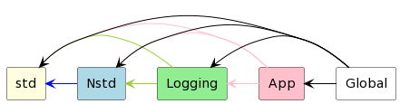

このように整理された依存関係は、 大規模ソフトウェア開発においては特に重要であり、決して循環しないように維持しなければならない。

### Nstdライブラリを使用したリファクタリング

すでに述べた通り、「operator<<を使わない」で導入したコードは、Nstdで定義するべきである。 その場合、下記のようにさらに一般化するのが良いだろう。

```cpp
    // @@@ example/template/nstd_0.h 4

    namespace Nstd {

    template <typename T>
    std::ostream& operator<<(std::ostream& os, std::vector<T> const& vec)
    {
        auto first = true;

        for (auto const& i : vec) {
            if (!std::exchange(first, false)) {
                os << ", ";
            }
            os << i;
        }

        return os;
    }

    template <typename T>
    std::string ToString(std::vector<T> const& vec)
    {
        auto oss = std::ostringstream{};

        oss << vec;

        return oss.str();
    }
    }  // namespace Nstd
```

その単体テストは下記のようになる。

```cpp
    // @@@ example/template/nstd_0_ut.cpp 13

    auto const ints = App::Ints_t{1, 2, 3};

    {
        auto oss = std::ostringstream{};

        using namespace Nstd;
        oss << ints << 4;
        ASSERT_EQ("1, 2, 34", oss.str());
    }
    {
        auto oss = std::ostringstream{};

        Nstd::operator<<(oss, ints) << 4;  // 念のためこの形式でもテスト
        ASSERT_EQ("1, 2, 34", oss.str());
    }

    ASSERT_EQ("1, 2, 3", Nstd::ToString(ints));
```

勘のいい読者なら、このコードをLOGGERから利用することで、 App:Ints_tのログ登録問題を解消できると思うかもしれない。 実際その通りなのであるが、そうした場合、 std::list等の他のコンテナや配列には対応できないという問題が残るため、 以降もしばらくNstdの開発を続ける。

### 安全なvector

std::vector、std::basic_string、std::array等の配列型コンテナは、

- operator[]経由でのメンバアクセスについて範囲の妥当性をチェックしない
- 範囲のチェックが必要ならばat()を使用する

という仕様になっているが、 ここではoperator[]にも範囲のチェックを行う配列型コンテナが必要になった場合について考える。

手始めにoperator[]にも範囲のチェックを行うstd::vector相当のコンテナSafeVectorを作ると、 下記のコードのようになる。

```cpp
    // @@@ example/template/safe_vector_ut.cpp 9

namespace Nstd {

template <typename T>
struct SafeVector : std::vector<T> {
    using std::vector<T>::vector;  // 継承コンストラクタ

    using base_type = std::vector<T>;
    using size_type = typename base_type::size_type;

    typename base_type::reference       operator[](size_type i) { return this->at(i); }
    typename base_type::const_reference operator[](size_type i) const { return this->at(i); }
};
}  // namespace Nstd
```

このコードで行ったことは、

- std::vectorからSafeVectorをpublic継承する
- 継承コンストラクタの機能を使い、std::vectorのコンストラクタをSafeVectorで宣言する
- std::vector::atを使い、SafeVector::operator[]を定義する

である。単体テストは下記のようになる。

```cpp
    // @@@ example/template/safe_vector_ut.cpp 29

    {
        auto v = Nstd::SafeVector<int>(10);  // ()での初期化

        ASSERT_EQ(10, v.size());
    }
    {
        auto const v = Nstd::SafeVector<int>{10};

        ASSERT_EQ(1, v.size());
        ASSERT_EQ(10, v[0]);
        ASSERT_THROW(v[1], std::out_of_range);  // エクセプションの発生
    }
    {
        auto v = Nstd::SafeVector<std::string>{"1", "2", "3"};

        ASSERT_EQ(3, v.size());
        ASSERT_EQ((std::vector<std::string>{"1", "2", "3"}), v);
        ASSERT_THROW(v[3], std::out_of_range);  // エクセプションの発生
    }
    {
        auto const v = Nstd::SafeVector<std::string>{"1", "2", "3"};

        ASSERT_EQ(3, v.size());
        ASSERT_EQ((std::vector<std::string>{"1", "2", "3"}), v);
        ASSERT_THROW(v[3], std::out_of_range);  // エクセプションの発生
    }
```

### 安全な配列型コンテナ

配列型コンテナはすでに述べたようにstd::vectorの他にすくなともstd::basic_string、 std::arrayがあるため、それらにも範囲チェックを導入する。

std::basic_stringはstd::vectorとほぼ同様に下記のようになる。

```cpp
    // @@@ example/template/safe_vector_ut.cpp 61
    namespace Nstd {

    struct SafeString : std::string {
        using std::string::string;  // 継承コンストラクタ

        using base_type = std::string;
        using size_type = typename base_type::size_type;

        typename base_type::reference       operator[](size_type i) { return this->at(i); }
        typename base_type::const_reference operator[](size_type i) const { return this->at(i); }
    };
    }  // namespace Nstd
```

std::stringはstd::basic_string<char>のエイリアスであるため、 上記では、通常使われる形式であるstd::stringを継承したSafeStringを定義した。

この単体テストはSafeVectorの場合と同様に下記のようになる。

```cpp
    // @@@ example/template/safe_vector_ut.cpp 79

    {
        auto s = Nstd::SafeString{"0123456789"};

        ASSERT_EQ(10, s.size());
        ASSERT_EQ("0123456789", s);
        ASSERT_THROW(s[10], std::out_of_range);
    }
    {
        auto const s = Nstd::SafeString(3, 'c');  // ()での初期化が必要

        ASSERT_EQ(3, s.size());
        ASSERT_EQ("ccc", s);
    }
```

std::arrayでは少々事情が異なるが、 std::vectorのコードパターンをそのまま適用すると下記のようになる。

```cpp
    // @@@ example/template/safe_vector_ut.cpp 100

    namespace Nstd {

    template <typename T, size_t N>
    struct SafeArray : std::array<T, N> {
        using std::array<T, N>::array;  // 継承コンストラクタ

        using base_type = std::array<T, N>;
        using size_type = typename base_type::size_type;

        typename base_type::reference       operator[](size_type i) { return this->at(i); }
        typename base_type::const_reference operator[](size_type i) const { return this->at(i); }
    };
    }  // namespace Nstd
```

ただし、この実装には問題がある。

```cpp
    // @@@ example/template/safe_vector_ut.cpp 121

    auto sa_not_init = Nstd::SafeArray<int, 3>{};

    ASSERT_EQ(3, sa_not_init.size());
    ASSERT_THROW(sa_not_init[3], std::out_of_range);
```

上記コードでは、その問題が露見することはないが、以下のコードはコンパイルできない。

```cpp
    // @@@ example/template/safe_vector_ut.cpp 131

    // std::initializer_listを引数とするコンストラクタが未定義
    auto sa_init = Nstd::SafeArray<int, 3>{1, 2, 3};

    // デフォルトコンストラクタがないため、未初期化
    Nstd::SafeArray<int, 3> const sa_const;
```

std::arrayにはコンストラクタが明示的に定義されていないため、 std::arrayにはデフォルトで自動生成される

- デフォルトコンストラクタ
- copyコンストラクタ
- moveコンストラクタ

以外のコンストラクタがないことが原因である。 従って、SafeArray(std::initializer_list)が定義されず前述したようにコンパイルエラーとなる。

この問題に対処したのが以下のコードである。

```cpp
    // @@@ example/template/safe_vector_ut.cpp 145

    namespace Nstd {

    template <typename T, size_t N>
    struct SafeArray : std::array<T, N> {
        using std::array<T, N>::array;  // 継承コンストラクタ
        using base_type = std::array<T, N>;

        template <typename... ARGS>  // コンストラクタを定義
        SafeArray(ARGS... args) : base_type{args...}
        {
        }

        using size_type = typename base_type::size_type;

        typename base_type::reference       operator[](size_type i) { return this->at(i); }
        typename base_type::const_reference operator[](size_type i) const { return this->at(i); }
    };
    }  // namespace Nstd
```

上記コードで注目すべきは、パラメータパックをテンプレートパラメータとしたコンストラクタである。 これにより、前例ではコンパイルすらできなかった下記のような初期化子リストを用いた単体テストが、 このコンストラクタによりパスするようになった。

```cpp
    // @@@ example/template/safe_vector_ut.cpp 180
    {
        auto sa_init = Nstd::SafeArray<int, 3>{1, 2, 3};

        ASSERT_EQ(3, sa_init.size());
        ASSERT_EQ(1, sa_init[0]);
        ASSERT_EQ(2, sa_init[1]);
        ASSERT_EQ(3, sa_init[2]);
        ASSERT_THROW(sa_init[3], std::out_of_range);
    }
    {
        auto const sa_string_const = Nstd::SafeArray<std::string, 5>{"1", "2", "3"};

        ASSERT_EQ(5, sa_string_const.size());
        ASSERT_EQ("1", sa_string_const[0]);
        ASSERT_EQ("2", sa_string_const[1]);
        ASSERT_EQ("3", sa_string_const[2]);
        ASSERT_EQ("", sa_string_const[3]);
        ASSERT_EQ("", sa_string_const[4]);
        ASSERT_THROW(sa_string_const[5], std::out_of_range);
    }
```

この効果を生み出した上記を抜粋した下記のコードには解説が必要だろう。

```cpp
    // @@@ example/template/safe_vector_ut.cpp 154

    template <typename... ARGS>  // コンストラクタを定義
    SafeArray(ARGS... args) : base_type{args...}
    {
    }
```

一般にコンストラクタには「メンバ変数の初期化」と「基底クラスの初期化」が求められるが、 SafeArrayにはメンバ変数が存在しないため、 このコンストラクタの役割は「基底クラスの初期化」のみとなる。 基底クラスstd::array(上記例ではbase_typeにエイリアスしている) には名前が非規定の配列メンバのみを持つため、 これを初期化するためには初期化子リスト (「初期化子リストコンストラクタ」、 「一様初期化」参照)を用いるのが良い。

ということは、SafeArrayの初期化子リストコンストラクタには、 「基底クラスstd::arrayに初期子リストを与えて初期化する」形式が必要になる。 値を持つパラメータパックは初期化子リストに展開できるため、 ここで必要な形式はパラメータパックとなる。 これを実現したのが上記に抜粋したわずか数行のコードである。

### 初期化子リストの副作用

上記SafeArrayの初期化子リストコンストラクタは以下のようなコードを許可しない。

```cpp
    // @@@ example/template/safe_vector_ut.cpp 212
    {
        auto sa_init = Nstd::SafeArray<int, 3>{1.0, 2, 3};

        ASSERT_EQ(3, sa_init.size());
        ASSERT_EQ(1, sa_init[0]);
        ASSERT_EQ(2, sa_init[1]);
        ASSERT_EQ(3, sa_init[2]);
        ASSERT_THROW(sa_init[3], std::out_of_range);
    }
```

このコードをコンパイルすると、

```
    safe_vector_ut.cpp:147:41: error: narrowing conversion of ‘
                                        args#0’ from ‘double’ to ‘int’ -Werror=narrowing]
      147 |     SafeArray(ARGS... args) : base_type{args...}
          |                                         ^~~~
```

のようなエラーが出力されるが、

- double(上記例では1.0)をintに変換する際に縮小変換(narrowing conversio)nが起こる
- 初期化子リストでの縮小変換は許可されない

が原因である。これは意図しない縮小変換によるバグを防ぐ良い機能だと思うが、 ここではテンプレートメタプログラミングのテクニックを解説するため、 あえてこのコンパイルエラーを起こさないSafeArray2を開発する (言うまでもないが、通常のソフトウェア開発では、 縮小変換によるコンパイルエラーを回避するようなコードを書いてはならない)。

SafeArray2のコードは、

- STLのtype_traitsの使用
- テンプレートの特殊化
- メンバ関数テンプレートとオーバーロードによる静的ディスパッチ(コンパイル時ディスパッチ)
- SFINAE

等のメタ関数系のテクニックが必要になるため、 まずはこれらを含めたテンプレートのテクニックについて解説し、 その後SafeArray2を見ていくことにする。

## メタ関数のテクニック

本章で扱うメタ関数とは、型、定数、クラステンプレート等からなるテンプレート引数から、 型、エイリアス、定数等を宣言、定義するようなクラステンプレート、関数テンプレート、 定数テンプレート、エイリアステンプレートを指す (本章ではこれらをまとめて単にテンプレート呼ぶことがある)。

### STLのtype_traits

メタ関数ライブラリの代表的実装例はSTLの [type_traits](https://cpprefjp.github.io/reference/type_traits.html)である。

ここでは、よく使ういくつかのtype_traitsテンプレートの使用例や解説を示す。

#### std::true_type/std::false_type

std::true_type/std::false_typeは真/偽を返すSTLメタ関数群の戻り型となる型エイリアスであるため、 最も使われるテンプレートの一つである。

これらは、下記で確かめられる通り、後述するstd::integral_constantを使い定義されている。

```cpp
    // @@@ example/template/type_traits_ut.cpp 13

    // std::is_same_vの2パラメータが同一であれば、std::is_same_v<> == true
    static_assert(std::is_same_v<std::integral_constant<bool, true>, std::true_type>);
    static_assert(std::is_same_v<std::integral_constant<bool, false>, std::false_type>);
```

それぞれの型が持つvalue定数は、下記のように定義されている。

```cpp
    // @@@ example/template/type_traits_ut.cpp 20

    static_assert(std::true_type::value, "must be true");
    static_assert(!std::false_type::value, "must be false");
```

これらが何の役に立つのか直ちに理解することは難しいが、 true/falseのメタ関数版と考えれば、追々理解できるだろう。

以下に簡単な使用例を示す。

```cpp
    // @@@ example/template/type_traits_ut.cpp 29

    // 引数の型がintに変換できるかどうかを判定する関数
    // decltypeの中でのみ使用されるため、定義は不要
    constexpr std::true_type  IsCovertibleToInt(int);  // intに変換できる型はこちら
    constexpr std::false_type IsCovertibleToInt(...);  // それ以外はこちら
```

上記の単体テストは下記のようになる。

```cpp
    // @@@ example/template/type_traits_ut.cpp 40

    static_assert(decltype(IsCovertibleToInt(1))::value);
    static_assert(decltype(IsCovertibleToInt(1u))::value);
    static_assert(!decltype(IsCovertibleToInt(""))::value);  // ポインタはintに変換不可

    struct ConvertibleToInt {
        operator int();
    };

    struct NotConvertibleToInt {};

    static_assert(decltype(IsCovertibleToInt(ConvertibleToInt{}))::value);
    static_assert(!decltype(IsCovertibleToInt(NotConvertibleToInt{}))::value);

    // なお、IsCovertibleToInt()やConvertibleToInt::operator int()は実際に呼び出されるわけでは
    // ないため、定義は必要なく宣言のみがあれば良い。
```

IsCovertibleToIntの呼び出しをdecltypeのオペランドにすることで、 std::true_typeかstd::false_typeを受け取ることができる。

#### std::integral_constant

std::integral_constantは 「テンプレートパラメータとして与えられた型とその定数から新たな型を定義する」 クラステンプレートである。

以下に簡単な使用例を示す。

```cpp
    // @@@ example/template/type_traits_ut.cpp 62

    using int3 = std::integral_constant<int, 3>;

    // std::is_same_vの2パラメータが同一であれば、std::is_same_v<> == true
    static_assert(std::is_same_v<int, int3::value_type>);
    static_assert(std::is_same_v<std::integral_constant<int, 3>, int3::type>);
    static_assert(int3::value == 3);

    using bool_true = std::integral_constant<bool, true>;

    static_assert(std::is_same_v<bool, bool_true::value_type>);
    static_assert(std::is_same_v<std::integral_constant<bool, true>, bool_true::type>);
    static_assert(bool_true::value == true);
```

また、すでに示したようにstd::true_type/std::false_typeを実装するためのクラステンプレートでもある。

#### std::is_same

すでに上記の例でも使用したが、std::is_sameは2つのテンプレートパラメータが

- 同じ型である場合、std::true_type
- 違う型である場合、std::false_type

から派生した型となる。

以下に簡単な使用例を示す。

```cpp
    // @@@ example/template/type_traits_ut.cpp 99

    static_assert(std::is_same<int, int>::value);
    static_assert(std::is_same<int, int32_t>::value);   // 64ビットg++/clang++
    static_assert(!std::is_same<int, int64_t>::value);  // 64ビットg++/clang++
    static_assert(std::is_same<std::string, std::basic_string<char>>::value);
    static_assert(std::is_same<typename std::vector<int>::reference, int&>::value);
```

また、 C++17で導入されたstd::is_same_vは、定数テンプレートを使用し、 下記のように定義されている。

```cpp
    // @@@ example/template/type_traits_ut.cpp 90

    template <typename T, typename U>
    constexpr bool is_same_v{std::is_same<T, U>::value};
```

```cpp
    // @@@ example/template/type_traits_ut.cpp 108

    static_assert(is_same_v<int, int>);
    static_assert(is_same_v<int, int32_t>);   // 64ビットg++/clang++
    static_assert(!is_same_v<int, int64_t>);  // 64ビットg++/clang++
    static_assert(is_same_v<std::string, std::basic_string<char>>);
    static_assert(is_same_v<typename std::vector<int>::reference, int&>);
```

このような簡潔な記述の一般形式は、

```
   T::value  -> T_v
   T::type   -> T_t
```

のように定義されている(このドキュメントのほとんど場所では、簡潔な形式を用いる)。

第1テンプレートパラメータが第2テンプレートパラメータの基底クラスかどうかを判断する std::is_base_ofを使うことで下記のようにstd::is_sameの基底クラス確認することもできる。

```cpp
    // @@@ example/template/type_traits_ut.cpp 117

    static_assert(std::is_base_of_v<std::true_type, std::is_same<int, int>>);
    static_assert(std::is_base_of_v<std::false_type, std::is_same<int, char>>);
```

#### std::enable_if

std::enable_ifは、bool値である第1テンプレートパラメータが

- trueである場合、型である第2テンプレートパラメータをメンバ型typeとして宣言する。
- falseである場合、メンバ型typeを持たない。

下記のコードはクラステンプレートの特殊化を用いたstd::enable_ifの実装例である。

```cpp
    // @@@ example/template/type_traits_ut.cpp 124

    template <bool T_F, typename T = void>
    struct enable_if;

    template <typename T>
    struct enable_if<true, T> {
        using type = T;
    };

    template <typename T>
    struct enable_if<false, T> {  // メンバエイリアスtypeを持たない
    };

    template <bool COND, typename T = void>
    using enable_if_t = typename enable_if<COND, T>::type;
```

std::enable_ifの使用例を下記に示す。

```cpp
    // @@@ example/template/type_traits_ut.cpp 148

    static_assert(std::is_same_v<void, std::enable_if_t<true>>);
    static_assert(std::is_same_v<int, std::enable_if_t<true, int>>);
```

実装例から明らかなように

- std::enable_if<true>::typeはwell-formed
- std::enable_if<false>::typeはill-formed

となるため、下記のコードはコンパイルできない。

```cpp
    // @@@ example/template/type_traits_ut.cpp 155

    // 下記はill-formedとなるため、コンパイルできない。
    static_assert(std::is_same_v<void, std::enable_if_t<false>>);
    static_assert(std::is_same_v<int, std::enable_if_t<false, int>>);
```

std::enable_ifのこの特性と後述するSFINAEにより、 様々な静的ディスパッチを行うことができる。

#### std::conditional

std::conditionalは、bool値である第1テンプレートパラメータが

- trueである場合、第2テンプレートパラメータ
- falseである場合、第3テンプレートパラメータ

をメンバ型typeとして宣言する。

下記のコードはクラステンプレートの特殊化を用いたstd::conditionalの実装例である。

```cpp
    // @@@ example/template/type_traits_ut.cpp 164

    template <bool T_F, typename, typename>
    struct conditional;

    template <typename T, typename U>
    struct conditional<true, T, U> {
        using type = T;
    };

    template <typename T, typename U>
    struct conditional<false, T, U> {
        using type = U;
    };

    template <bool COND, typename T, typename U>
    using conditional_t = typename conditional<COND, T, U>::type;
```

std::conditionalの使用例を下記に示す。

```cpp
    // @@@ example/template/type_traits_ut.cpp 189

    static_assert(std::is_same_v<int, std::conditional_t<true, int, char>>);
    static_assert(std::is_same_v<char, std::conditional_t<false, int, char>>);
```

#### std::is_void

std::is_voidはテンプレートパラメータの型が

- voidである場合、std::true_type
- voidでない場合、std::false_type

から派生した型となる。

以下に簡単な使用例を示す。

```cpp
    // @@@ example/template/type_traits_ut.cpp 82

    static_assert(std::is_void<void>::value);
    static_assert(!std::is_void<int>::value);
    static_assert(!std::is_void<std::string>::value);
```

### is_void_xxxの実装

ここではstd::is_voidに似た以下のような仕様を持ついくつかのテンプレートis_void_xxxの実装を考える。

| テンプレートパラメータ | 戻り値 |
| --- | --- |
| void | true |
| 非void | false |

それぞれのis_void_xxxは下記テーブルで示した言語機能を使用して実装する。

| is_void_xxx | 実装方法 |
| --- | --- |
| is_void_f | 関数テンプレートの特殊化 |
| is_void_s | クラステンプレートの特殊化 |
| is_void_sfinae_f | SFINAEと関数テンプレートのオーバーロード |
| is_void_sfinae_s | SFINAEとクラステンプレートの特殊化 |
| is_void_ena_s | std::enable_ifによるSFINAEとクラステンプレートの特殊化 |
| is_void_cond_s | std::conditionalと関数テンプレートの特殊化 |

なお、実装例をシンプルに保つため、 理解の妨げとなり得る下記のような正確性(例外条件の対応)等のためのコードを最低限に留めた。

- テンプレートパラメータの型のチェック
- テンプレートパラメータの型からのポインタ/リファレンス/const/volatileの削除
- 戻り型からのconst/volatileの削除

これは、「テンプレートプログラミングでの有用なテクニックの解説」 というここでの目的を見失わないための措置である。

#### is_void_fの実装

関数テンプレートの特殊化を使用したis_void_fの実装は以下のようになる。

```cpp
    // @@@ example/template/is_void_ut.cpp 7

    template <typename T>
    constexpr bool is_void_f() noexcept
    {
        return false;
    }

    template <>
    constexpr bool is_void_f<void>() noexcept
    {
        return true;
    }

    template <typename T>
    constexpr bool is_void_f_v{is_void_f<T>()};
```

単純なので解説は不要だろう。これらの単体テストは下記のようになる。

```cpp
    // @@@ example/template/is_void_ut.cpp 27

    static_assert(!is_void_f_v<int>);
    static_assert(!is_void_f_v<std::string>);
    static_assert(is_void_f_v<void>);
```

関数テンプレートの特殊化には、

- 特殊化された関数テンプレートとそのプライマリテンプレートのシグネチャ、 戻り値は一致しなければならない
- クラステンプレートのような部分特殊化は許可されない

のような制限があるため用途は限られるが、関数テンプレートはオーバーロードすることが可能である。

#### is_void_sの実装

クラステンプレートの特殊化を使用したis_void_sの実装は以下のようになる。

```cpp
    // @@@ example/template/is_void_ut.cpp 35

    template <typename T>
    struct is_void_s {
        static constexpr bool value{false};
    };

    template <>
    struct is_void_s<void> {
        static constexpr bool value{true};
    };

    template <typename T>
    constexpr bool is_void_s_v{is_void_s<T>::value};
```

is_void_fと同様に単純なので解説は不要だろう。これらの単体テストは下記のようになる。

```cpp
    // @@@ example/template/is_void_ut.cpp 53

    static_assert(!is_void_s_v<int>);
    static_assert(!is_void_s_v<std::string>);
    static_assert(is_void_s_v<void>);
```

#### is_void_sfinae_fの実装

SFINAEを使用した関数テンプレートis_void_sfinae_fの実装は以下のようになる。

```cpp
    // @@@ example/template/is_void_ut.cpp 61

    namespace Inner_ {

    // T == void
    template <typename T>
    constexpr auto is_void_sfinae_f_detector(void const* v, T const* t) noexcept
        -> decltype(t = v, bool{})  // T != voidの場合、t = vはill-formed
                                    // T == voidの場合、well-formedでbool型生成
    {
        return true;
    }

    // T != void
    template <typename T>
    constexpr auto is_void_sfinae_f_detector(void const*, T const*) noexcept
        -> decltype(sizeof(T), bool{})  // T != voidの場合、well-formedでbool型生成
                                        // T == voidの場合、sizeof(T)はill-formed
    {
        return false;
    }
    }  // namespace Inner_

    template <typename T>
    constexpr bool is_void_sfinae_f() noexcept
    {
        return Inner_::is_void_sfinae_f_detector(nullptr, static_cast<T*>(nullptr));
    }

    template <typename T>
    constexpr bool is_void_sfinae_f_v{is_void_sfinae_f<T>()};
```

関数テンプレートである2つのis_void_sfinae_f_detectorのオーバーロードにSFINAEを使用している。

1つ目のis_void_sfinae_f_detectorでは、

| T | t = v の診断(コンパイル) |
| --- | --- |
| == void | well-formed |
| != void | ill-formed |

であるため、Tがvoidの時のみname lookupの対象になる。

2つ目のis_void_sfinae_f_detectorでは、

| T | sizeof(T)の診断(コンパイル) |
| --- | --- |
| == void | ill-formed |
| != void | well-formed |

であるため、Tが非voidの時のみname lookupの対象になる。

is_void_sfinae_fはこの性質を利用し、

- T == voidの場合、1つ目のis_void_sfinae_f_detectorが選択され、戻り値はtrue
- T != voidの場合、2つ目のis_void_sfinae_f_detectorが選択され、戻り値はfalse

となる。念のため単体テストを示すと下記のようになる。

```cpp
    // @@@ example/template/is_void_ut.cpp 96

    static_assert(!is_void_sfinae_f_v<int>);
    static_assert(!is_void_sfinae_f_v<std::string>);
    static_assert(is_void_sfinae_f_v<void>);
```

一般にファイル外部に公開するテンプレートは、 コンパイルの都合上ヘッダファイルにその全実装を記述することになる。 これは、本来外部公開すべきでない実装の詳細である is_void_sfinae_f_detectorのようなテンプレートに関しては大変都合が悪い。 というのは、外部から使用されたくない実装の詳細が使われてしまうことがあり得るからである。 上記の例では、こういうことに備え 「これは外部非公開である」ということを示す名前空間Inner_ を導入した。

関数テンプレートはクラステンプレート内にも定義することができるため、 is_void_sfinae_fは下記のように実装することも可能である。この場合、名前空間Inner_は不要になる。

```cpp
    // @@@ example/template/is_void_ut.cpp 105

    template <typename T>
    class is_void_sfinae_f {
        // U == void
        template <typename U>
        static constexpr auto detector(void const* v, U const* u) noexcept
            -> decltype(u = v, bool{})  // U != voidの場合、t = vはill-formed
                                        // U == voidの場合、well-formedでbool型生成
        {
            return true;
        }

        // U != void
        template <typename U>
        static constexpr auto detector(void const*, U const*) noexcept
            -> decltype(sizeof(U), bool{})  // U != voidの場合、well-formedでbool型生成
                                            // U == voidの場合、ill-formed
        {
            return false;
        }

    public:
        static constexpr bool value{is_void_sfinae_f::detector(nullptr, static_cast<T*>(nullptr))};
    };

    template <typename T>
    constexpr bool is_void_sfinae_f_v{is_void_sfinae_f<T>::value};
```

```cpp
    // @@@ example/template/is_void_ut.cpp 137

    static_assert(!is_void_sfinae_f_v<int>);
    static_assert(!is_void_sfinae_f_v<std::string>);
    static_assert(is_void_sfinae_f_v<void>);
```

#### is_void_sfinae_sの実装

SFINAEを使用したクラステンプレートis_void_sfinae_sの実装は以下のようになる。

```cpp
    // @@@ example/template/is_void_ut.cpp 146

    namespace Inner_ {
    template <typename T>
    T*& t2ptr();  // 定義は不要
    }  // namespace Inner_

    template <typename T, typename = void*&>
    struct is_void_sfinae_s : std::false_type {
    };

    template <typename T>
    struct is_void_sfinae_s<
        T,
        // T != voidの場合、ill-formed
        // T == voidの場合、well-formedでvoid*&生成
        decltype(Inner_::t2ptr<T>() = Inner_::t2ptr<void>())

        > : std::true_type {
    };

    template <typename T>
    constexpr bool is_void_sfinae_s_v{is_void_sfinae_s<T>::value};
```

1つ目のis_void_sfinae_sはプライマリテンプレートである。 is_void_sfinae_sの特殊化がname lookupの対象の中に見つからなかった場合、 これが使われる。

2つ目のis_void_sfinae_sは、上記を抜粋した下記のコード

```cpp
    // @@@ example/template/is_void_ut.cpp 162

    // T != voidの場合、ill-formed
    // T == voidの場合、well-formedでvoid*&生成
    decltype(Inner_::t2ptr<T>() = Inner_::t2ptr<void>())
```

がT == voidの時のみ、well-formedになり、このテンプレートは下記のようにインスタンス化される。

```cpp
    struct is_void_sfinae_s<void, void*&>
```

この形状はプライマリテンプレートの

- 第1パラメータにvoidを与える
- 第2パラメータには何も与えない(デフォルトのまま)

とした場合の、つまりプライマリテンプレートを

```cpp
    struct is_void_sfinae_s<void>   // プライマリテンプレート
```

としてインスタンス化した場合と一致する。 プライマリと特殊化が一致した場合、特殊化されたものがname lookupで選択される。

T != voidの場合、 2つ目のis_void_sfinae_sはill-formedになり、name lookupの対象から外れるため、 プライマリが選択される。

以上をまとめると、

| T | is_void_sfinae_sの基底クラス |
| --- | --- |
| == void | std::true_type |
| != void | std::false_type |

となる。以下の単体テストによって、このことを確かめることができる。

```cpp
    // @@@ example/template/is_void_ut.cpp 179

    static_assert(!is_void_sfinae_s_v<int>);
    static_assert(std::is_base_of_v<std::false_type, is_void_sfinae_s<int>>);

    static_assert(!is_void_sfinae_s_v<std::string>);
    static_assert(std::is_base_of_v<std::false_type, is_void_sfinae_s<std::string>>);

    static_assert(is_void_sfinae_s_v<void>);
    static_assert(std::is_base_of_v<std::true_type, is_void_sfinae_s<void>>);
```

上記コードのように「プライマリテンプレートのデフォルトパラメータ」と、

```cpp
    // @@@ example/template/is_void_ut.cpp 162

    // T != voidの場合、ill-formed
    // T == voidの場合、well-formedでvoid*&生成
    decltype(Inner_::t2ptr<T>() = Inner_::t2ptr<void>())
```

が「well-formedであった場合に生成される型」が一致することを利用した静的ディスパッチは、 SFINAEとクラステンプレートの特殊化を組み合わせたメタ関数の典型的な実装パターンである。 ただし、一般にはill-formedを起こすためにst::enable_ifを使うことが多いため、 「is_void_ena_sの実装」でその例を示す。

#### is_void_ena_sの実装

std::enable_ifによるSFINAEとクラステンプレートの特殊化を使用した is_void_ena_sの実装は以下のようになる。

```cpp
    // @@@ example/template/is_void_ut.cpp 192
    template <typename T, typename = void>
    struct is_void_ena_s : std::false_type {
    };

    template <typename T>
    struct is_void_ena_s<
        T,
        typename std::enable_if_t<is_void_f<T>()>
        > : std::true_type {
    };

    template <typename T>
    constexpr bool is_void_ena_s_v{is_void_ena_s<T>::value};
```

この例では、「is_void_sfinae_sの実装」の

```cpp
    // @@@ example/template/is_void_ut.cpp 162

    // T != voidの場合、ill-formed
    // T == voidの場合、well-formedでvoid*&生成
    decltype(Inner_::t2ptr<T>() = Inner_::t2ptr<void>())
```

で示したSFINAEの処理を上記を抜粋した下記のコード

```cpp
    // @@@ example/template/is_void_ut.cpp 202

    typename std::enable_if_t<is_void_f<T>()>
```

で行っている。 std::enable_ifの値パラメータis_void_f<T>()は、「is_void_fの実装」で示したものである。

単体テストは、「is_void_sfinae_sの実装」で示したものとほぼ同様で、以下のようになる。

```cpp
    // @@@ example/template/is_void_ut.cpp 216

    static_assert(!is_void_ena_s_v<int>);
    static_assert(std::is_base_of_v<std::false_type, is_void_ena_s<int>>);

    static_assert(!is_void_ena_s_v<std::string>);
    static_assert(std::is_base_of_v<std::false_type, is_void_ena_s<std::string>>);

    static_assert(is_void_ena_s_v<void>);
    static_assert(std::is_base_of_v<std::true_type, is_void_ena_s<void>>);
```

#### is_void_cond_sの実装

std::conditionalと関数テンプレートの特殊化を使用したis_void_cond_sの実装は以下のようになる。

```cpp
    // @@@ example/template/is_void_ut.cpp 229
    template <typename T>
    struct is_void_cond_s : std::conditional_t<is_void_f<T>(), std::true_type, std::false_type> {
    };

    template <typename T>
    constexpr bool is_void_cond_s_v{is_void_cond_s<T>::value};
```

std::conditionalの値パラメータis_void_f<T>()は、「is_void_fの実装」で示したものである。 この例では、SFINAEもクラステンプレートの特殊化も使用していないが、 下記単体テストからわかる通り、「is_void_sfinae_sの実装」と同じ機能を備えている。

```cpp
    // @@@ example/template/is_void_ut.cpp 240

    static_assert(!is_void_cond_s_v<int>);
    static_assert(std::is_base_of_v<std::false_type, is_void_cond_s<int>>);

    static_assert(!is_void_cond_s_v<std::string>);
    static_assert(std::is_base_of_v<std::false_type, is_void_cond_s<std::string>>);

    static_assert(is_void_cond_s_v<void>);
    static_assert(std::is_base_of_v<std::true_type, is_void_cond_s<void>>);
```